# Tema 8: Flujos en redes

Optimización y Análisis de Redes

DSLAB

2026-10-12

## Objetivos de aprendizaje

1. **Formular** algebraicamente el concepto de flujo y circulación en digrafos mediante las ecuaciones de conservación y balance en los nodos.
2. **Caracterizar** la estructura vectorial de los flujos, calculando las bases fundamentales de ciclos y el número ciclomático $\nu(G)$.
3. **Demostrar** y **aplicar** el Lema de Coloración de Arcos de Minty mediante su algoritmo constructivo de etiquetado de vértices.
4. **Demostrar** y **analizar** el Teorema de Flujo Máximo - Corte Mínimo de Ford-Fulkerson y la relación de dualidad en optimización lineal.
5. **Ejecutar** y **caracterizar** el algoritmo de Ford-Fulkerson en redes residuales mediante el método de etiquetado directo y la cota de Edmonds-Karp.
6. **Formular** y **resolver** los problemas de flujo a coste mínimo y el problema general del transbordo.

# Estructura algebraica de flujos, ciclos y cociclos

## Introducción y contexto físico

- **Representación de redes de flujo**:
  - Digrafo conexo $G = (V, U)$ con $n = |V|$ vértices y $m = |U|$ arcos dirigidos.
  - Modela la circulación de bienes (tráfico vehicular, fluidos, información, electricidad, capitales).
- **Leyes físicas y topológicas**:
  - Los flujos responden a leyes de conservación local en los vértices (análogas a las leyes de Kirchhoff en circuitos o continuidad en fluidos).
- **Estructura matemática del problema**:
  - Álgebra lineal aplicada sobre la topología del digrafo.
  - Dualidad estricta entre circulaciones cerradas (ciclos) y barreras de corte (cociclos).

## Definición: Flujo en un digrafo y conservación

**Flujo en un digrafo y conservación**

Dado un digrafo conexo $G = (V, U)$ con $m$ arcos dirigidos, un **flujo** es un vector $\mathbf{f} = (f_{u_1}, f_{u_2}, \dots, f_{u_m})^T \in \mathbb{R}^m$ cuyas componentes representan el caudal $f_u$ que transita por cada arco $u \in U$, satisfaciendo la **ley de conservación de flujo** en todos los vértices:

$$\sum_{u \in w^+(i)} f_u = \sum_{u \in w^-(i)} f_u, \quad \forall i \in V$$

donde $w^+(i)$ son los arcos salientes del nodo $i$ y $w^-(i)$ los arcos entrantes al nodo $i$.

## Nota de notación: Arcos, vectores y componentes

**Distinción entre arcos, vectores y componentes**

Para evitar cualquier confusión entre los nombres de los arcos y los valores numéricos del flujo:

1. **Identificador del Arco**: Los $m$ arcos del digrafo se etiquetan como $u_1, u_2, \dots, u_m \in U$ (o por pares ordenados $u = (i, j)$).
2. **Identificador de Vectores (Superíndices)**: Los distintos vectores de flujo o de ciclo se denotan en negrita mediante **superíndices** ($\mathbf{f}^1, \mathbf{f}^2, \mathbf{f}^3$; $\mathbf{\mu}^1, \mathbf{\mu}^2$).
3. **Componentes Escalares de Arco (Subíndices)**: El caudal por el arco $u_k$ se denota mediante el **subíndice** $f_{u_k}$ (o $f_{ij}$). En los gráficos, se especifica el arco y su valor ($u_k: f_{u_k}$).

## Balances nodales y tipos de nodos

- **Escalar de balance $b_i \in \mathbb{R}$ en cada nodo $i \in V$**:
  - **Nodo fuente ($b_i > 0$)**: Inyecta $b_i$ unidades netas de flujo a la red.
  - **Nodo sumidero ($b_i < 0$)**: Extrae $|b_i|$ unidades netas de flujo de la red.
  - **Nodo de transbordo ($b_i = 0$)**: La suma entrante iguala a la saliente (nodo de paso).
- **Condición de equilibrio global**:
  $$\sum_{i \in V} b_i = 0$$
- **Concepto de Circulación**:
  - Cuando $b_i = 0$ para todo $i \in V$, la red no posee entradas ni salidas externas.
  - El vector de flujo $\mathbf{f}$ se denomina estrictamente **circulación**.

## Ejemplo: Representación gráfica de los tres vectores

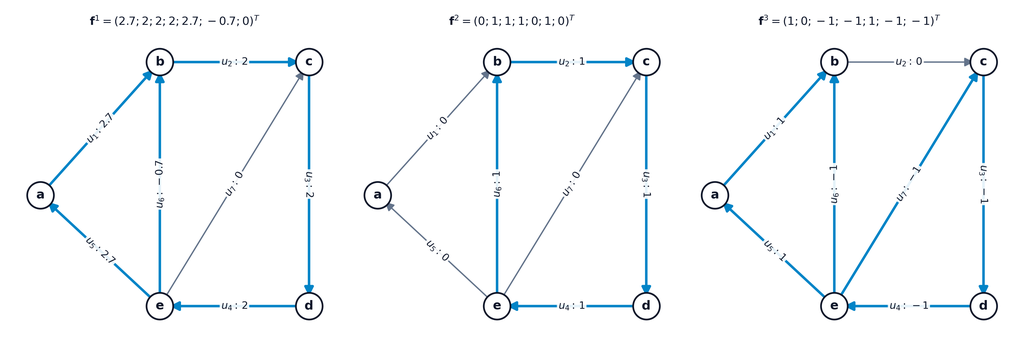

- Representación visual de los vectores de flujo $\mathbf{f}^1$, $\mathbf{f}^2$ y $\mathbf{f}^3$ evaluados sobre la red de 5 nodos.

## Ejemplo: Evaluación del vector de flujo f1

Considérese el digrafo de 5 nodos y 7 arcos para evaluar el primer vector de flujo $\mathbf{f}^1 \in \mathbb{R}^7$:

- **Vector $\mathbf{f}^1 = (2.7;\, 2;\, 2;\, 2;\, 2.7;\, -0.7;\, 0)^T$**:
  - Nodo $a$: Salen $f_1 = 2.7$, entran $f_5 = 2.7 \implies 2.7 = 2.7$.
  - Nodo $b$: Salen $f_2 = 2$, entran $f_1 + f_6 = 2.7 + (-0.7) = 2 \implies 2 = 2$.
  - Nodo $e$: Salen $f_5 + f_6 + f_7 = 2.7 - 0.7 + 0 = 2$, entra $f_4 = 2 \implies 2 = 2$.
  - *Conclusión*: Cumple la ley de conservación en todos los nodos $\implies$ **Flujo válido**.

## Ejemplo: Evaluación de los vectores f2 y f3

Evaluación de los siguientes dos vectores de flujo en la misma red:

- **Vector $\mathbf{f}^2 = (0;\, 1;\, 1;\, 1;\, 0;\, 1;\, 0)^T$**:
  - Flujo circulante por el ciclo formado por los arcos $u_2, u_3, u_4, u_6$.
  - Satisface la conservación en todos los vértices.
- **Vector $\mathbf{f}^3 = (1;\, 0;\, -1;\, -1;\, 1;\, -1;\, -1)^T$**:
  - Satisface las ecuaciones de conservación en los 5 nodos.

## Lema: Flujo nulo en árboles

**Flujo nulo en árboles**

Un flujo definido sobre un árbol (digrafo conexo acíclico) es necesariamente el **flujo nulo** ($\mathbf{f} = \mathbf{0}$).

- **Demostración inductiva**:
  - Todo árbol de $n$ vértices posee $n - 1$ arcos y contiene al menos una hoja $x_1$ de grado 1.
  - Sea $u$ el único arco incidente en $x_1$. Por conservación, $f_u = 0$.
  - Retirando inductivamente la hoja $x_1$, se deduce que todas las componentes son nulas: $f_u = 0, \forall u \in U$.
- **Conclusión fundamental**: La presencia de **ciclos cerrados es estrictamente necesaria** para sostener circulaciones no nulas en una red.

## Lema: Estructura vectorial del espacio de flujos

**Estructura vectorial del espacio de flujos**

Cualquier combinación lineal de flujos es un flujo. En consecuencia, el conjunto de flujos definidos sobre un digrafo $G = (V, U)$ forma un espacio vectorial.

- **Clausura algebraica**:
  - Si $\mathbf{f}^1$ y $\mathbf{f}^2$ son flujos y $\alpha, \beta \in \mathbb{R}$, entonces $\alpha \mathbf{f}^1 + \beta \mathbf{f}^2$ es un flujo factible.
  - La suma y el escalado de circulaciones preservan exactamente la conservación nodal.
- **Objetivo de caracterización**:
  - Identificar la dimensión de este espacio vectorial y construir una **base de flujos**.

## Ejemplo: Representación del flujo resultante

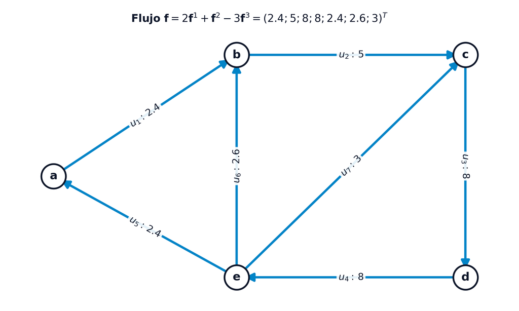

- El flujo resultante $\mathbf{f} = (2.4;\, 5;\, 8;\, 8;\, 2.4;\, 2.6;\, 3)^T$ satisface la conservación en todos los nodos y constituye un flujo factible bien definido.

## Ejemplo: Combinación lineal de vectores de flujo

Considérense los tres vectores de flujo $\mathbf{f}^1, \mathbf{f}^2, \mathbf{f}^3 \in \mathbb{R}^7$. Evaluamos la combinación lineal:

$$\mathbf{f} = 2\mathbf{f}^1 + \mathbf{f}^2 - 3\mathbf{f}^3$$

$$\begin{aligned}
\mathbf{f} &= 2(2.7;\, 2;\, 2;\, 2;\, 2.7;\, -0.7;\, 0)^T + (0;\, 1;\, 1;\, 1;\, 0;\, 1;\, 0)^T - 3(1;\, 0;\, -1;\, -1;\, 1;\, -1;\, -1)^T \\
&= (2.4;\, 5;\, 8;\, 8;\, 2.4;\, 2.6;\, 3)^T
\end{aligned}$$

## Ejemplo: Verificación de conservación en los vértices

- **Verificación nodo a nodo del flujo $\mathbf{f} = (2.4;\, 5;\, 8;\, 8;\, 2.4;\, 2.6;\, 3)^T$**:
  - **Nodo $a$**: Salen $f_1 = 2.4$, entran $f_5 = 2.4 \implies 2.4 = 2.4$.
  - **Nodo $b$**: Salen $f_2 = 5$, entran $f_1 + f_6 = 2.4 + 2.6 = 5 \implies 5 = 5$.
  - **Nodo $c$**: Salen $f_3 = 8$, entran $f_2 + f_7 = 5 + 3 = 8 \implies 8 = 8$.
  - **Nodo $d$**: Salen $f_4 = 8$, entran $f_3 = 8 \implies 8 = 8$.
  - **Nodo $e$**: Salen $f_5 + f_6 + f_7 = 2.4 + 2.6 + 3 = 8$, entra $f_4 = 8 \implies 8 = 8$.

## Definición de ciclo y clasificación de arcos

- **Concepto de Ciclo**:
  - Cadena simple $\mu$ (sin repetir arcos) cuyo nodo inicial y final coinciden.
  - Al fijar un sentido de giro de referencia, los arcos del digrafo se clasifican en:
- **Clasificación de arcos**:
  - **Arcos positivos ($u \in \mu^+$)**: Su orientación en el digrafo coincide con el sentido del ciclo.
  - **Arcos negativos ($u \in \mu^-$)**: Su orientación en el digrafo es opuesta al sentido del ciclo.
  - **Arcos neutros ($u \notin \mu$)**: Arcos fuera de la cadena del ciclo.
- **Inversión de giro**:
  - Invertir la orientación de referencia intercambia los arcos positivos y negativos ($\mu^+ \leftrightarrow \mu^-$).

## Clasificación visual de arcos en un ciclo

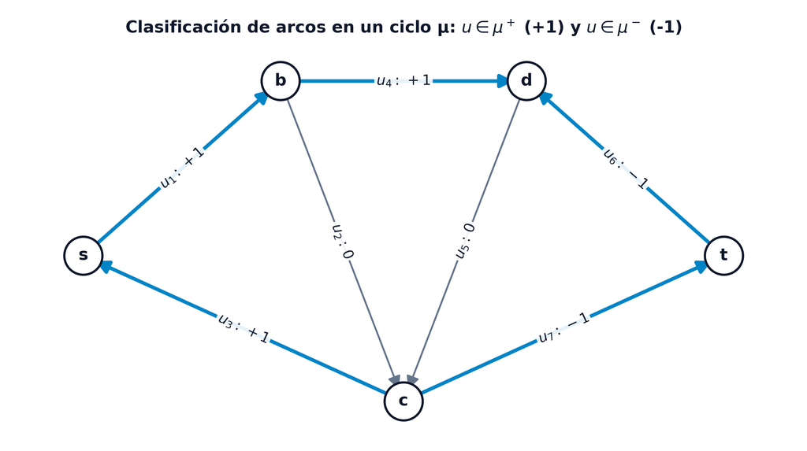

- Al recorrer la red según el sentido de giro elegido:
  - Arcos directos o positivos ($\mu^+$): $1, 4, 3$.
  - Arcos opuestos o negativos ($\mu^-$): $6, 7$.

## Definición: Vector característico de un ciclo

**Vector característico de un ciclo**

Un ciclo $\mu$ se representa algebraicamente mediante un vector característico $\mathbf{\mu} = (\mu_1, \mu_2, \dots, \mu_m)^T \in \mathbb{R}^m$, donde la componente asociada a cada arco $u \in U$ se define como:

$$\mu_u = \begin{cases}
+1 & \text{si } u \in \mu^+ \\
-1 & \text{si } u \in \mu^- \\
0 & \text{si } u \notin \mu
\end{cases}$$

- Traduce la estructura combinatoria de un ciclo a un vector de entradas $\{-1, 0, 1\}$ en $\mathbb{R}^m$.

## Ejemplo: Digrafo de referencia para vectores de ciclos

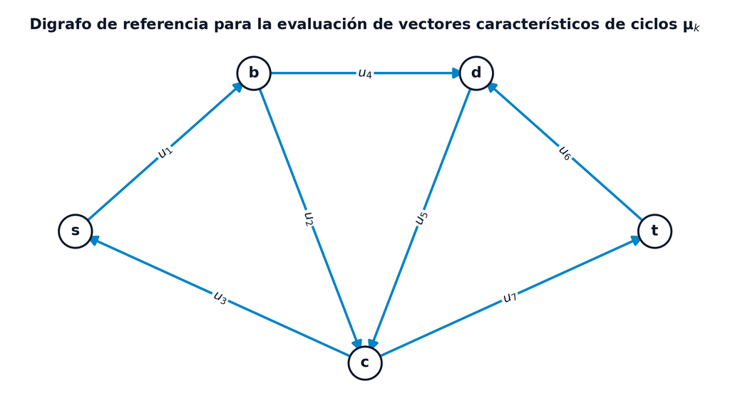

- Digrafo de 5 nodos y 7 arcos utilizado para la evaluación de los vectores característicos de ciclos $\mathbf{\mu}_1 \dots \mathbf{\mu}_5$.

## Ejemplo: Vectores característicos de ciclos

Considérese el digrafo de referencia de 5 nodos $s, b, c, d, t$ y 7 arcos. Se identifican los siguientes ciclos $\mathbf{\mu}_k \in \mathbb{R}^7$:

## Representación gráfica: Ciclos como flujos

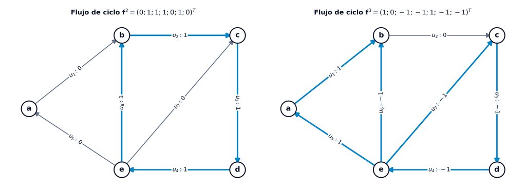

- Los vectores $\mathbf{f}^2 = (0;\, 1;\, 1;\, 1;\, 0;\, 1;\, 0)^T$ y $\mathbf{f}^3 = (1;\, 0;\, -1;\, -1;\, 1;\, -1;\, -1)^T$ son flujos válidos generados por ciclos que satisfacen la conservación en todos los nodos.

## Proposición: Los ciclos son flujos

**Los ciclos son flujos**

El vector característico $\mathbf{\mu}$ asociado a cualquier ciclo en un digrafo es un flujo.

- **Verificación de la conservación nodal**:
  - Para $i \notin \mu$: Ningún arco incidente pertenece al ciclo $\implies 0 = 0$.
  - Para $i \in \mu$: El ciclo entra por un arco $u_{in}$ y sale por $u_{out}$.
  - Analizando la orientación respecto al giro (positivo o negativo), la contribución al balance entrante $\sum f_{in}$ es igual a la del saliente $\sum f_{out}$.

## Corolario: Variación de flujo mediante ciclos

**Variación de flujo mediante ciclos**

Dado un flujo $\mathbf{f}$ en un digrafo $G$ y un ciclo $\mathbf{\mu}$, el vector resultante de sumar a $\mathbf{f}$ el vector asociado al ciclo multiplicado por una constante $\alpha \in \mathbb{R}$ ($\mathbf{f}' = \mathbf{f} + \alpha \mathbf{\mu}$) es también un flujo en $G$.

- Permite modificar localmente el caudal de una red sin alterar el equilibrio de los nodos.

## Definición: Independencia de flujos

**Independencia de flujos**

Dado un digrafo $G = (V, U)$, un conjunto de flujos $\{\mathbf{f}^1, \mathbf{f}^2, \dots, \mathbf{f}^k\}$ es linealmente independiente si sus correspondientes vectores en $\mathbb{R}^m$ son linealmente independientes.

- La independencia lineal garantiza que ninguno de los flujos de la base pueda construirse combinando los restantes.

## Teorema: Base fundamental de ciclos

**Base fundamental de ciclos**

Sea $G = (V, U)$ un digrafo conexo con $n$ vértices y $m$ arcos, y sea $H = (V, T)$ un árbol soporte de $G$ (formado por $n - 1$ arcos).

Al añadir a $T$ cualquier arco fuera del árbol $u \in U \setminus T$, se forma un único ciclo elemental $\mu^u$ en $G$ tal que $\mu^u_u = 1$. El conjunto de ciclos $H = \{\mu^u \mid u \in U \setminus T\}$ constituye una **base del espacio vectorial de flujos** del digrafo $G$.

- **Aclaración teórica**: El número de vectores de ciclo necesarios para generar cualquier circulación en el digrafo queda determinado exclusivamente por la cantidad de arcos fuera del árbol soporte ($\nu(G) = m - n + 1$).

## Definición: Número ciclomático

**Número ciclomático**

Se define el **número ciclomático** $\nu(G)$ de un digrafo conexo $G = (V, U)$ como la dimensión del espacio vectorial de sus flujos:

$$\nu(G) = m - n + 1$$

- Basta con identificar $m - n + 1$ cuerdas fuera del árbol soporte para caracterizar unívocamente todo el espacio de circulaciones.

## Ejemplo: Base de ciclos - Planteamiento y Pasos

Considérese el digrafo de $n = 5$ nodos y $m = 7$ arcos. Su número ciclomático es $\nu(G) = 7 - 5 + 1 = 3$.

- **Paso 1: Selección del Árbol Soporte y Cuerdas**
  - Árbol soporte $T = \{u_1, u_4, u_5, u_7\}$ (4 arcos en **azul**).
  - Cuerdas o arcos no básicos $U \setminus T = \{u_2, u_3, u_6\}$ (3 arcos en **gris**).
- **Paso 2: Generación de los 3 Ciclos Fundamentales**
  1. Añadir $u_2 = (b, c) \implies \mathbf{\mu}^2 = (1, 1, 0, 0, 1, 0, -1)^T$.
  2. Añadir $u_3 = (c, d) \implies \mathbf{\mu}^3 = (0, 0, 1, 1, 0, 0, 1)^T$.
  3. Añadir $u_6 = (e, b) \implies \mathbf{\mu}^6 = (-1, 0, 0, 0, -1, 1, 0)^T$.
- **Paso 3: Descomposición Unívoca de un Flujo** Dado el flujo $\mathbf{f} = (3, 4, 6, 6, 3, 1, 2)^T$, sus coordenadas en la base son $f_{u_2} = 4, f_{u_3} = 6, f_{u_6} = 1$:
  $$\mathbf{f} = 4 \mathbf{\mu}^2 + 6 \mathbf{\mu}^3 + 1 \mathbf{\mu}^6$$

## Ejemplo: Animación interactiva con controles

[interactive chart not shown]

## Definición: Cociclo (Corte)

**Cociclo (Corte)**

Dado un digrafo conexo $G = (V, U)$ y un subconjunto propio no vacío de vértices $A \subset V$, se define el **cociclo** $w(A)$ como el subconjunto de arcos que tienen un extremo en $A$ y el otro en $V \setminus A$:

$$w(A) = w^+(A) \cup w^-(A)$$

donde $w^+(A)$ son los arcos salientes de $A$ y $w^-(A)$ los arcos entrantes a $A$.

## Definición: Vector característico de un cociclo

**Vector característico de un cociclo**

Un cociclo $w(A)$ se representa algebraicamente mediante un vector característico $\mathbf{\theta} = (\theta_1, \theta_2, \dots, \theta_m)^T \in \mathbb{R}^m$, cuyas componentes se definen como:

$$\theta_u = \begin{cases}
+1 & \text{si } u \in w^+(A) \\
-1 & \text{si } u \in w^-(A) \\
0 & \text{si } u \notin w(A)
\end{cases}$$

## Representación gráfica de un cociclo

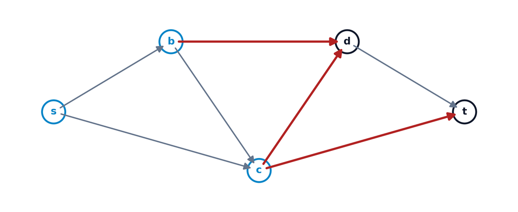

## Ejemplo: Representación gráfica de los dos cociclos

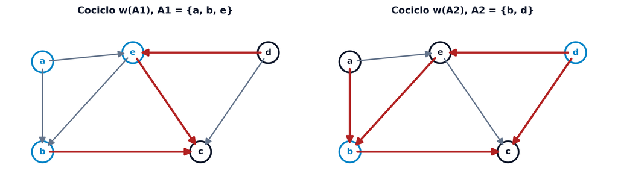

- Comparativa visual de las particiones $A_1 = \{a, b, e\}$ (izquierda) y $A_2 = \{b, d\}$ (derecha) con sus respectivos vectores característicos $\mathbf{\theta}^1$ y $\mathbf{\theta}^2$.

## Ejemplo: Evaluación de vectores de cociclo (Parte 1)

Evaluación de dos particiones sobre la red de 5 nodos y 7 arcos:

1. **Subconjunto $A_1 = \{a, b, e\}$**:
   - Nodos $a, b, e$ en la región izquierda ($A_1$) y $c, d$ en la derecha ($V \setminus A_1$).
   - Arcos internos a $A_1$: $u_1, u_5, u_6 \implies \theta = 0$.
   - Arcos salientes $w^+(A_1)$: $u_2=(b,c)$ y $u_7=(e,c) \implies \theta_{u_2} = 1, \theta_{u_7} = 1$.
   - Arcos entrantes $w^-(A_1)$: $u_4=(d,e) \implies \theta_{u_4} = -1$.
   - Arcos externos a $A_1$: $u_3=(c,d) \implies \theta_{u_3} = 0$.
   - Vector característico de $w(A_1)$:
     $$\mathbf{\theta}^1 = (0;\, 1;\, 0;\, -1;\, 0;\, 0;\, 1)^T$$

## Ortogonalidad fundamental entre ciclos y cociclos

- **Producto Escalar Nulo**: Para cualquier ciclo $\mathbf{\mu}$ y cualquier cociclo $\mathbf{\theta}$ sobre el mismo digrafo $G = (V, U)$:

  $$\mathbf{\mu}^T \mathbf{\theta} = \sum_{u \in U} \mu_u \theta_u = 0$$
- **Significado Físico**:
  - El caudal neto transportado por cualquier circulación cerrada a través de un corte topológico es idénticamente nulo.

## Subespacios ortogonales complementarios

- **Subespacios Ortogonales en $\mathbb{R}^m$**:
  - Espacio de Flujos $\mathcal{C}$ ($\dim = m - n + 1$).
  - Espacio de Cociclos $\mathcal{C}^*$ ($\dim = n - 1$).
- **Suma directa ortogonal**:
  $$\mathbb{R}^m = \mathcal{C} \oplus \mathcal{C}^*$$
- **Complementariedad dimensional**:
  $$(m - n + 1) + (n - 1) = m$$

## Lema: Coloración de arcos de Minty

**Coloración de arcos de Minty**

Sea $G = (V, U)$ un digrafo conexo cuyos arcos se encuentran coloreados con cuatro opciones: **negro** ($N$), **verde** ($V$), **rojo** ($R$) o **sin color** ($0$), existiendo al menos un arco negro $u_0 \in U$.

Entonces se cumple **una y solo una** de las dos aseveraciones:

1. El arco negro $u_0$ pertenece a un **ciclo elemental** coloreado (arcos negros positivos, verdes negativos y rojos arbitrarios).
2. El arco negro $u_0$ pertenece a un **cociclo elemental** coloreado (arcos negros en $w^+(A)$, verdes en $w^-(A)$ y sin color arbitrarios).

## Demostración constructiva de Minty (Algoritmo)

- **Sea el arco negro $u_0 = (t, s)$**:
  - **Paso 1: Etiquetado inicial**: Asignar $p(s) = s$. El resto $p(j) = 0$.
  - **Paso 2: Propagación de etiquetas**: Dado $i \in A$ ($p(i) \neq 0$) y $j \notin A$ ($p(j) = 0$), asignar $p(j) = i$ si:
    - Existe el arco saliente $(i, j)$ coloreado de **negro** o **rojo**.
    - Existe el arco entrante $(j, i)$ coloreado de **verde** o **rojo**.
  - **Paso 3: Criterio de parada**:
    - **Caso A ($p(t) \neq 0$)**: Se alcanza $t \implies$ **Ciclo elemental** de $t$ a $s$ con $u_0$.
    - **Caso B ($p(t) = 0$)**: No se alcanza $t \implies$ **Cociclo elemental** sobre $A = \{i \mid p(i) \neq 0\}$.

## Ejemplo Minty: Representación gráfica

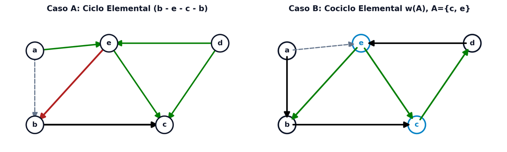

- Izquierda: Propagación de marcas hasta alcanzar el nodo origen $b$ (Caso A - Ciclo).
- Derecha: Propagación detenida sin alcanzar $b$ (Caso B - Cociclo).

## Ejemplo Minty - Caso A y Caso B

- **Caso A: Generación de un Ciclo** (Gráfico Izquierdo)
  - Arco negro $u_0 = (b, c)$. Arco $(e, b)$ en **rojo**; $(e, c), (d, c), (d, e), (a, e)$ en **verde**.
  - Propagación: $p(c)=c \to p(e)=c \to p(d)=c \to p(b)=e$.
  - Se alcanza $b \implies$ Ciclo $\mu = \{(e, b), (e, c), (b, c)\}$.
- **Caso B: Generación de un Cociclo** (Gráfico Derecho)
  - Arco negro $u_0 = (b, c)$. Arcos $(e, b), (e, c), (c, d)$ en **verde**; $(d, e), (a, b)$ en **negro**.
  - Propagación: $p(c)=c \to p(e)=c$. Los arcos salientes verdes no admiten marca $\implies p(b)=0$.
  - Cociclo $w(A)$ sobre $A = \{c, e\}$ con $u_0 \in w^-(A)$.

## Observación: Elementalidad de los ciclos y cociclos

**Elementalidad de los ciclos y cociclos de Minty**

1. **Elementalidad del Ciclo**: Al alcanzar el origen $t$, la asignación de antecesores $p(j)$ asigna un único padre a cada nodo, impidiendo vértices duplicados en la trayectoria de retorno.
2. **Elementalidad del Cociclo**: La partición $A$ (etiquetados) y $V \setminus A$ (no etiquetados) genera subgrafos inducidos $G[A]$ y $G[V \setminus A]$ conexos por construcción inductiva del etiquetado.

# El problema del flujo máximo

## Introducción al problema del flujo máximo

- **Motivación estratégica**:
  - Determinar el volumen máximo de mercancía, datos o fluidos que puede enviarse desde un nodo fuente $s$ a un nodo sumidero $t$.
  - Respetar la capacidad física máxima $c_u$ de cada conexión.
- **Relevancia práctica**:
  - Logística de distribución y transporte.
  - Capacidad de tráfico en redes de comunicaciones e infraestructuras.

## Definición: Red de transporte

**Red de transporte**

Una **red de transporte** es un par $(G = (V, U), \mathbf{c})$, donde $G = (V, U)$ es un digrafo conexo sin bucles y $\mathbf{c} = \{c_u \mid u \in U\}$ representa el conjunto de **capacidades** superiores no negativas asociadas a cada arco $u \in U$ ($c_u \ge 0$).

- La capacidad $c_u$ fija la cota física máxima de caudal por el arco $u$.

## Definición: Flujo compatible (preliminar)

**Flujo compatible (versión preliminar)**

Dada una red de transporte $(G, \mathbf{c})$, se define un **flujo compatible** como un vector $\mathbf{f} \in \mathbb{R}^m$ que satisface:

1. **Ley de conservación pura**: $\sum_{u \in w^+(i)} f_u = \sum_{u \in w^-(i)} f_u, \quad \forall i \in V$.
2. **Compatibilidad con capacidades**: $0 \le f_u \le c_u, \quad \forall u \in U$.

## Paradoja de la conservación nula en s y t

- **Conflicto en la fuente $s$ y el sumidero $t$**:
  - De la fuente $s$ solo salen arcos ($w^-(s) = \emptyset$). Si exigimos conservación pura, $\sum_{entrantes} f_u = 0 \implies \sum_{salientes} f_u = 0 \implies f_u = 0, \forall u \in w^+(s)$.
  - Al sumidero $t$ solo entran arcos ($w^+(t) = \emptyset$). Exigir conservación pura impone $\sum_{entrantes} f_u = 0$.
- **Efecto de bloqueo**:
  - Exigir conservación estricta en todos los nodos sin excepción fuerza a que el **único flujo compatible sea el flujo nulo** ($\mathbf{f} = \mathbf{0}$).

## Ilustración: Paradoja del flujo nulo

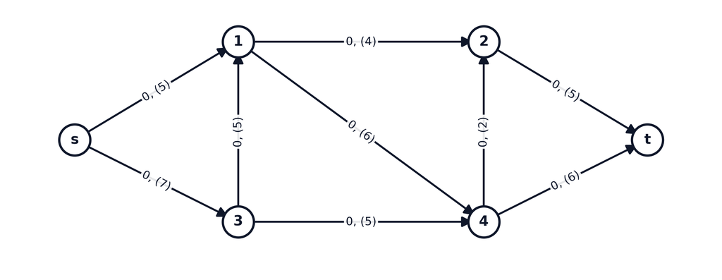

- Si se impone la ley de conservación pura en $s$ y $t$, la única solución admisible es $\mathbf{f} = \mathbf{0}$, impidiendo el envío de flujo útil.

## Concepto: Arco ficticio de retorno

- **Construcción del arco ficticio de retorno $u_0 = (t, s)$**:
  - Se conecta el sumidero $t$ de regreso a la fuente $s$ mediante $u_0 = (t, s)$ con capacidad ilimitada ($c_0 = \infty$).
  - Todo el flujo que llega a $t$ recircula de vuelta a $s$, convirtiendo el transporte en una **circulación cerrada**.
- **Valor del flujo $v(\mathbf{f})$**:
  - El caudal por el arco ficticio representa el flujo neto transportado:
    $$f_0 = v(\mathbf{f}) = \sum_{j \in \Gamma^+(s)} f_{sj} = \sum_{j \in \Gamma^-(t)} f_{jt}$$

## Definición: (s,t)-Flujo compatible

**(s, t)-Flujo compatible**

Dada una red de transporte $(G = (V, U), \mathbf{c})$ y dos vértices $s, t \in V$, un **$(s, t)$-flujo compatible** es una circulación factible sobre la red ampliada $G' = (V, U \cup \{u_0=(t,s)\})$ con $c_0 = \infty$, tal que $0 \le f_u \le c_u, \forall u \in U$.

- Permite formular la conservación en **todos** los nodos incluyendo $s$ y $t$.

## Ilustración: Red ampliada con retorno ficticio

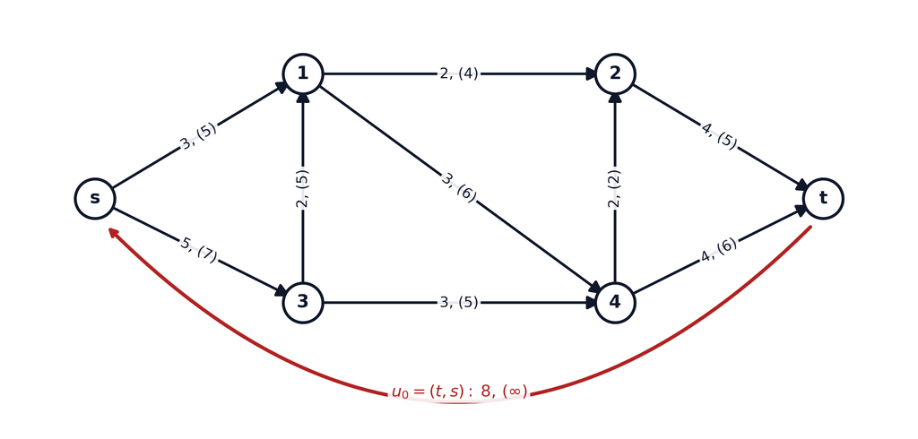

- El arco ficticio $u_0 = (t, s)$ lleva un valor de flujo $f_0 = 8$, permitiendo cerrar la red y definir $v(\mathbf{f}) = 8$.

## Formulación del problema del flujo máximo

**Problema del flujo máximo**

Dada una red de transporte $(G = (V, U), \mathbf{c})$ y dos vértices $s, t \in V$, el **problema del flujo máximo** consiste en determinar un $(s, t)$-flujo compatible $\mathbf{f}^* \in \mathbb{R}^m$ que maximice el valor $f_0$ del arco de retorno $u_0 = (t, s)$:

$$\begin{aligned}
\max_{\mathbf{f} \in \mathbb{R}^m} \quad & f_0 = \sum_{j \in \Gamma^+(s)} f_{sj} = \sum_{j \in \Gamma^-(t)} f_{jt} \\
\text{s.a.} \quad & \sum_{u \in w^+(i)} f_u - \sum_{u \in w^-(i)} f_u = 0, \quad \forall i \in V \\
& 0 \le f_u \le c_u, \quad \forall u \in U
\end{aligned}$$

## Ejemplo: Evaluación gráfica de compatibilidad

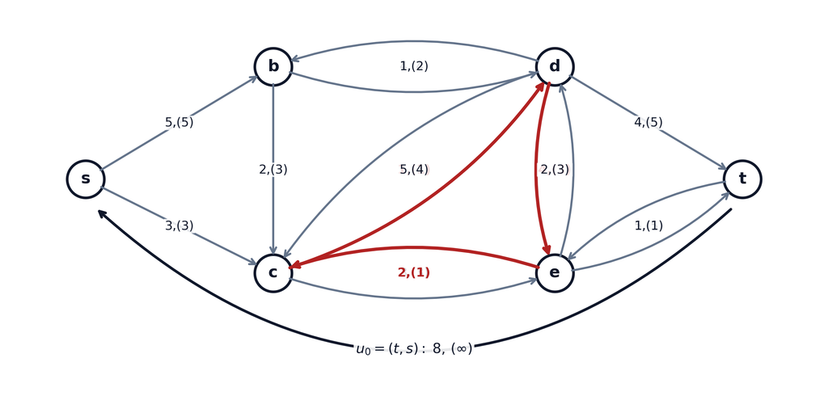

- Evaluación de la compatibilidad de caudales sobre una red de 6 nodos con un valor de flujo $f_0 = 8$.

## Ejemplo: Red de tráfico urbano

- **Planteamiento**: Red vial con intersecciones $V = \{s, a, b, t\}$ y capacidades $c_u$ (vehículos por minuto):
  - $c_{sa} = 100$, $c_{sb} = 100$, $c_{ab} = 50$, $c_{at} = 75$, $c_{bt} = 100$.

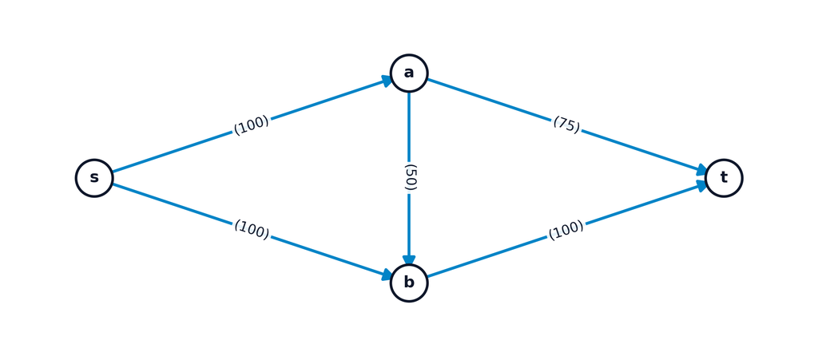

## Ejemplo: Resolución del tráfico urbano

- **Análisis de cuellos de botella**:
  - Inyección desde la fuente $s$: $c_{sa} + c_{sb} = 100 + 100 = 200$ veh/min.
  - Capacidad de llegada al sumidero $t$: $c_{at} + c_{bt} = 75 + 100 = 175$ veh/min.
- **Conclusión**:
  - Aunque $s$ puede emitir 200 veh/min, las vías de acceso a $t$ restringen el paso a un máximo de 175 veh/min.
  - Valor del flujo máximo: $v(\mathbf{f}^*) = 175$ veh/min.

## Ejemplo: Asignación de tareas a empleados

- **Planteamiento**: 3 empleados ($E_1, E_2, E_3$) y 3 tareas ($T_1, T_2, T_3$) con arcos de compatibilidad.

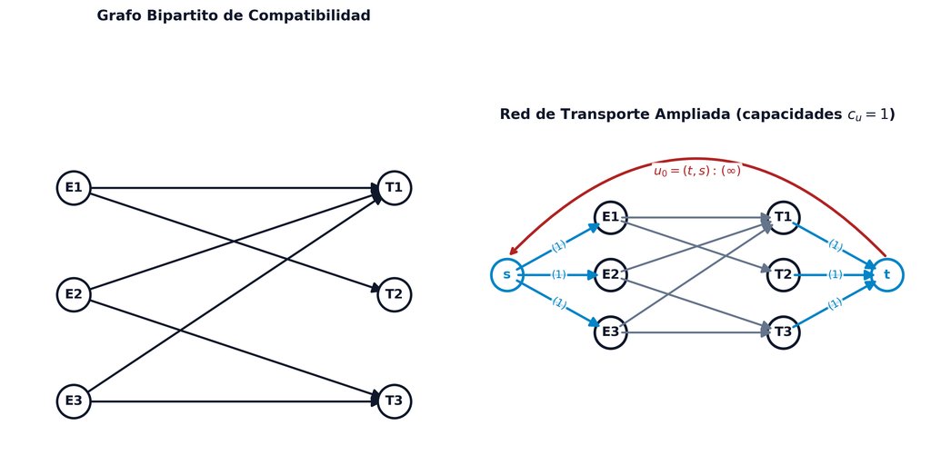

## Ejemplo: Asignación de tareas (Transformación)

- **Transformación a Red de Transporte**:
  1. Nodo fuente $s$ conectado a cada empleado $E_i$ con $c_{s E_i} = 1$ (1 tarea por empleado).
  2. Arcos de compatibilidad $(E_i, T_j)$ con capacidad $c_{E_i T_j} = 1$.
  3. Nodo sumidero $t$ conectado desde cada tarea $T_j$ con $c_{T_j t} = 1$ (1 empleado por tarea).
  4. Arco ficticio de retorno $u_0 = (t, s)$ con $c_0 = \infty$.
- Resolver el flujo máximo sobre la red equivale a hallar el número máximo de tareas ejecutables.

## Esquema iterativo de aumento de flujo

- **Procedimiento iterativo general**:
  1. **Flujo Inicial**: Comenzar con un flujo compatible válido $\mathbf{f}^0$ sobre la red (típicamente el flujo trivial nulo $\mathbf{f}^0 = \mathbf{0}$).
  2. **Búsqueda de Aumento**: Buscar un nuevo flujo compatible $\mathbf{f}^{k+1}$ que incremente el valor circulante por el arco de retorno $f_0$.
  3. **Iteración y Criterio de Parada**: Repetir el procedimiento a partir del nuevo flujo hasta que no sea posible realizar ningún incremento adicional.
- **Justificación algebraica**:
  - Toda diferencia entre flujos $\mathbf{f}^2 - \mathbf{f}^1$ es una **combinación lineal de ciclos**.
  - Para aumentar $f_0$, el algoritmo busca un ciclo que incluya al arco ficticio $u_0 = (t, s)$ y admita un incremento de caudal.

## Definición: Cadena incremental y ciclo incremental

**Cadena incremental**

Dado un flujo compatible $\mathbf{f}$ en la red $(G, \mathbf{c})$, una cadena $\mu[a, b]$ entre $a$ y $b$ es una **cadena incremental** (o camino aumentante) si satisface:

$$f_u < c_u, \quad \forall u \in \mu^+ \qquad \text{y} \qquad f_u > 0, \quad \forall u \in \mu^-$$

**Ciclo incremental**

Un **ciclo incremental** es una cadena incremental cerrada. En el flujo máximo, se busca una cadena incremental entre $s$ y $t$ que complete con $u_0 = (t, s)$ un ciclo incremental.

## Definición: Capacidad residual

**Capacidad residual de una cadena**

La **capacidad residual** $c(\mu)$ de una cadena incremental $\mu[s, t]$ es el máximo flujo adicional que puede enviarse a través de ella:

$$c(\mu) = \min \left\{ \min_{u \in \mu^+} (c_u - f_u), \, \min_{u \in \mu^-} f_u \right\}$$

- Aumentando el flujo en $+c(\mu)$ en arcos directos $u \in \mu^+$ y reduciéndolo en $-c(\mu)$ en arcos inversos $u \in \mu^-$, el valor total $f_0$ aumenta exactamente en $c(\mu)$ unidades manteniendo la compatibilidad estricta.

## Flujo máximo en grafos no dirigidos: Planteamiento

- **Tránsito bidireccional en aristas no dirigidas**:
  - En redes sobre un grafo no dirigido $G = (V, E)$, cada arista $e = \{a, b\}$ con capacidad $c_e$ admite flujo en ambas direcciones: $(a, b)$ y $(b, a)$.
  - **Restricción de capacidad global**:
    $$f_{(a,b)} + f_{(b,a)} \le c_e, \qquad f_{(a,b)} \ge 0, \quad f_{(b,a)} \ge 0$$
- **Necesidad de transformación**:
  - Para aplicar algoritmos de flujo sobre digrafos, se debe reemplazar cada arista no dirigida por un **gadget dirigido** que impida el tránsito simultáneo en ambos sentidos.

## Definición: Gadget de 5 arcos dirigidos

**Transformación de aristas no dirigidas (Gadget de 5 arcos)**

Cada arista no dirigida $e = \{a, b\}$ con capacidad $c_e = c$ se sustituye por un conjunto de **cinco arcos dirigidos** y dos vértices auxiliares $a', b'$:

$$U_e = \{ (a, a'), \, (b, a'), \, (a', b'), \, (b', a), \, (b', b) \}$$

asignando capacidad $c$ a todos los arcos del conjunto $U_e$.

## Ilustración: Gadget de 5 arcos

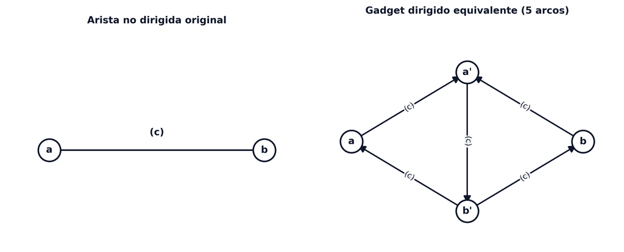

- Transformación de una arista no dirigida $\{a, b\}$ de capacidad $c$ (izquierda) en un gadget equivalente de 5 arcos dirigidos con nodos auxiliares $a', b'$ (derecha).

## Funcionamiento y equivalencia del gadget

- **Tránsito de $a$ hacia $b$**:
  - El flujo sigue el camino $a \to a' \to b' \to b$, atravesando el arco central $(a', b')$ con capacidad $c$.
- **Tránsito de $b$ hacia $a$**:
  - El flujo sigue el camino $b \to a' \to b' \to a$, atravesando el **mismo** arco central $(a', b')$.
- **Garantía de compatibilidad**:
  - Como ambas direcciones deben atravesar obligatoriamente el arco central $(a', b')$, se satisface de forma automática $f_{(a,b)} + f_{(b,a)} \le c$, impidiendo la circulación simultánea contrapuesta.

## Flujo máximo y corte mínimo: Planteamiento

- **Conexión entre flujo y barreras topológicas**:
  - El flujo máximo entre $s$ y $t$ no está restringido solo por capacidades individuales, sino por barreras que separan el origen del destino.
- **Concepto de corte**:
  - Partición de los nodos en dos conjuntos que aísla la fuente $s$ en un lado y el sumidero $t$ en el otro.

## Definición: (s,t)-Corte

**(s, t)-Corte**

Dada la red de transporte $(G = (V, U), \mathbf{c})$, un **corte que separa $s$ y $t$** o **$(s, t)$-corte** es el conjunto de arcos salientes $w^+(N)$ asociado a un subconjunto de vértices $N \subset V$ tal que $s \in N$ y $t \notin N$.

## Definición: Capacidad de un corte

**Capacidad de un corte**

Dada la red de transporte $(G = (V, U), \mathbf{c})$, se define la **capacidad de un $(s, t)$-corte** como la suma de las capacidades de los arcos salientes que lo componen:

$$c(w^+(N)) = \sum_{u \in w^+(N)} c_u$$

## Definición: Problema de corte de mínima capacidad

**Problema de corte de mínima capacidad**

El **problema de corte de mínima capacidad** consiste en determinar la partición $N \subset V$ ($s \in N, t \notin N$) que minimice la capacidad del corte:

$$\min_{\substack{N \subset V \\ s \in N, \, t \notin N}} c(w^+(N)) = \sum_{u \in w^+(N)} c_u$$

## Proposición: Acotación del flujo por la capacidad del corte

**Acotación del flujo por la capacidad del corte**

Para cualquier $(s, t)$-flujo compatible $\mathbf{f}$ y cualquier $(s, t)$-corte $w^+(N)$, el valor del flujo está acotado superiormente por la capacidad del corte:

$$f_0 \le c(w^+(N)) = \sum_{u \in w^+(N)} c_u, \qquad \forall N \subset V \, (s \in N, t \notin N)$$

## Interpretación: Acotación por cuellos de botella

- **Interpretación física de la cota**:
  - Todo el flujo que se desplaza de $s$ a $t$ debe cruzar de forma obligatoria cualquier $(s, t)$-corte.
  - Ningún $(s, t)$-flujo puede superar la capacidad del corte más estrecho:
    $$\max f_0 \le \min_{\substack{N \subset V \\ s \in N, \, t \notin N}} c(w^+(N))$$

## Ejemplo: Evaluación gráfica de cortes

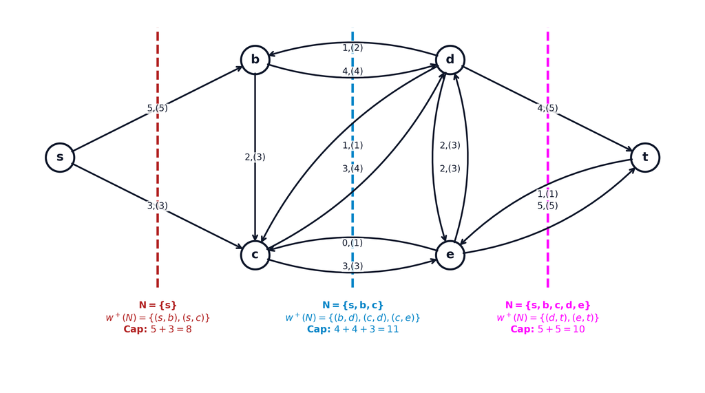

- Evaluación de tres $(s, t)$-cortes sobre la red de 6 nodos con un flujo circulante de valor $f_0 = 8$.

## Ejemplo: Evaluación de 3 cortes y capacidades

Evaluación de los tres cortes sobre la red de 6 nodos:

1. **Corte 1 ($N_1 = \{s\}$)** (línea roja teja):
   - $w^+(N_1) = \{(s, b), (s, c)\} \implies c(w^+(N_1)) = 5 + 3 = 8$.
2. **Corte 2 ($N_2 = \{s, b, c\}$)** (línea azul cerúleo):
   - $w^+(N_2) = \{(b, d), (c, d), (c, e)\} \implies c(w^+(N_2)) = 4 + 4 + 3 = 11$.
3. **Corte 3 ($N_3 = \{s, b, c, d, e\}$)** (línea magenta):
   - $w^+(N_3) = \{(d, t), (e, t)\} \implies c(w^+(N_3)) = 5 + 5 = 10$.

## Ejemplo: Criterio de optimalidad

- **Comparación entre flujo y capacidad de corte**:
  - El flujo de $s$ a $t$ transita con $f_0 = 8$.
  - La capacidad del Corte 1 es $c(w^+(N_1)) = 8$.
- **Conclusión de optimalidad**:
  - Como $f_0 = 8 = c(w^+(N_1))$, por la Proposición de Acotación:
    - El flujo $\mathbf{f}$ es un **flujo máximo global**.
    - El corte $w^+(N_1)$ es un **corte de capacidad mínima**.

## Corolario: Criterio de optimalidad simultánea

**Criterio de optimalidad de flujo máximo y corte mínimo**

Si un flujo compatible $\mathbf{f}$ y un $(s, t)$-corte $w^+(N)$ satisfacen $f_0 = c(w^+(N))$, entonces $\mathbf{f}$ es el **flujo máximo** de $s$ a $t$ y $w^+(N)$ es el **corte de mínima capacidad**.

- Ningún otro flujo puede superar $c(w^+(N)) = f_0$, y ningún otro corte puede tener capacidad inferior a $f_0$.

## Corolario: Existencia y acotación de solución

**Existencia de solución finita**

El problema del flujo máximo de $s$ a $t$ tiene solución finita si y sólo si no existe un camino orientado de $s$ a $t$ formado íntegramente por arcos de capacidad infinita ($c_u = \infty, \forall u \in \mu$).

- Si no existe tal camino, el conjunto $N$ de alcanzables desde $s$ en $G'=(V, U_\infty)$ forma un corte $w^+(N)$ con $c(w^+(N)) < \infty \implies f_0 \le c(w^+(N)) < \infty$.

## Teorema: Flujo máximo - corte mínimo

**Flujo máximo - corte mínimo (Ford-Fulkerson, 1956)**

Dada una red de transporte $(G = (V, U), \mathbf{c})$ y dos vértices $s, t \in V$, el $(s, t)$-flujo máximo coincide exactamente con la mínima capacidad de los $(s, t)$-cortes:

$$\max_{\mathbf{f}} f_0 = \min_{\substack{N \subset V \\ s \in N, \, t \notin N}} c(w^+(N))$$

## Interpretación combinatoria de Ford-Fulkerson

- **Dualidad Min-Max en redes**:
  - Establece la igualdad estricta entre la máxima cantidad de flujo transmisible y la mínima capacidad que puede bloquear la red.
  - Garantiza la existencia de una barrera saturada cuando el flujo alcanza su valor óptimo global.

## Ejemplo Minty: Planteamiento y Coloración de Arcos

- Considérese la red de 6 nodos $V = \{s, 1, 2, 3, 4, t\}$ con flujo $f_0 = 10$ y retorno $u_0 = (t, s)$:
- **Reglas de coloración según caudales actuales**:
  - Arco de retorno $u_0 = (t, s)$ ($f_0 = 10, c_0 = \infty$): **Negro** (admite aumento).
  - Arco $(3, 1)$ ($f_{31} = 0, c_{31} = 5$): **Negro** ($0 = f_{31} < c_{31}$).
  - Arcos a capacidad máxima: $(1,2)$, $(1,4)$, $(3,4)$, $(4,2)$: **Verdes** ($0 < f_u = c_u$).
  - Arcos a capacidad intermedia: $(s,1)$, $(s,3)$, $(2,t)$, $(4,t)$: **Rojos** ($0 < f_u < c_u$).

## Ejemplo Minty: Gráfico y Marcado de Vértices

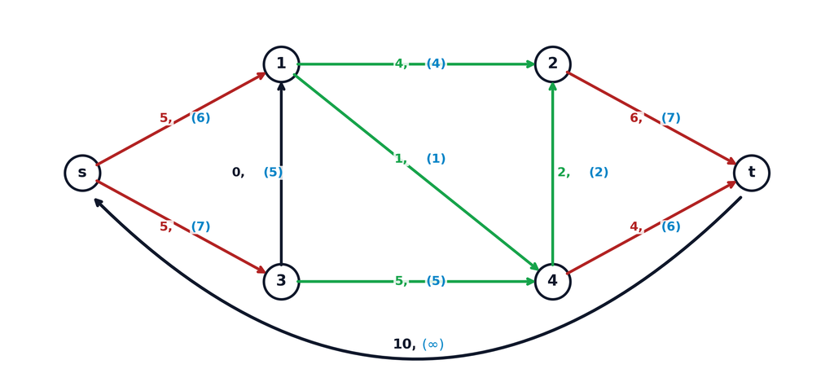

- **Propagación del marcado desde la fuente**:
  - Inicio: $S = \{s\}$.
  - Vía arcos rojos salientes $(s,1)$ y $(s,3) \implies S = \{s, 1, 3\}$.
  - Arcos salientes de $1$ y $3$ son verdes (bloqueados); entrantes son negros $\implies$ Marcado final $S = \{s, 1, 3\}$.

## Ejemplo Minty: Verificación de Optimalidad

- **Análisis de la partición $S = \{s, 1, 3\}$**:
  - El sumidero $t \notin S \implies$ No existe cadena incremental de $s$ a $t$.
  - La partición $N = \{s, 1, 3\}$ define un $(s, t)$-corte válido.
- **Capacidad del corte $w^+(N)$**:
  - Arcos salientes $w^+(N) = \{(1,2), (1,4), (3,4)\}$ (todos verdes).
  - $c(w^+(N)) = c_{12} + c_{14} + c_{34} = 4 + 1 + 5 = 10$.
- **Conclusión**: $f_0 = 10 = c(w^+(N)) \implies$ El flujo $\mathbf{f}$ es **óptimo global** y $w^+(N)$ es **corte de capacidad mínima**.

## Ejemplo Minty: Análisis de Sensibilidad (Red62)

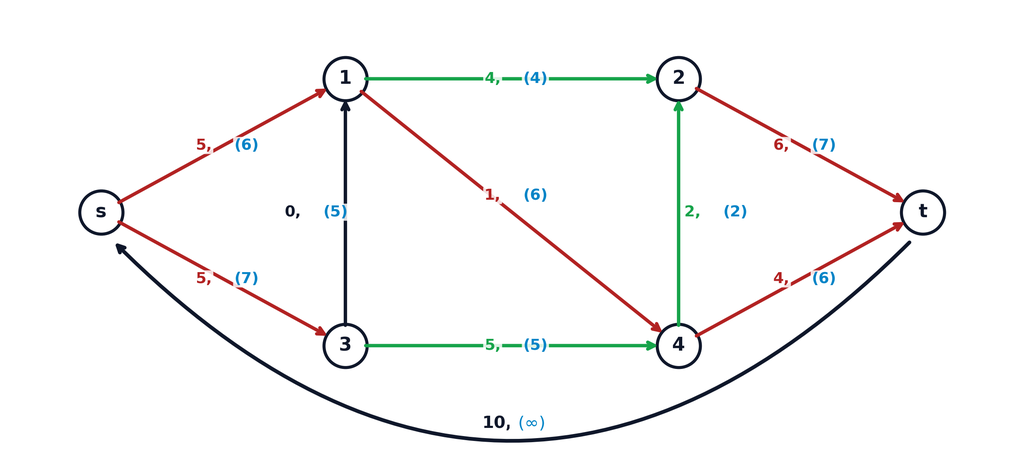

- **Modificación de capacidad**: Al elevar $c_{14} = 6$ manteniéndose $f_{14} = 1$:
  - El arco $(1,4)$ pasa de verde a **rojo** ($0 < 1 < 6$).
  - Desde $1 \in S$, el arco rojo $(1,4)$ marca el nodo $4$, y el rojo $(4,t)$ marca finalmente el sumidero $t \implies$ ¡Se habilita el incremento de flujo vía $s \to 1 \to 4 \to t$!

## Algoritmo de Ford-Fulkerson: Introducción

- **Orígenes y fundamento**:
  - Publicado en 1956 por L. R. Ford (1927–2017) y D. R. Fulkerson (1924–1976).
  - Denominado también **algoritmo del camino de aumento**.
- **Idea central**:
  - Incrementar progresivamente el caudal de la red a lo largo de trayectorias orientadas no saturadas (cadenas incrementales) desde la fuente $s$ hasta el sumidero $t$.
- **Criterio de parada y optimalidad**:
  - El algoritmo finaliza cuando no es posible hallar ninguna trayectoria adicional de aumento.

## Definición: Red residual (Grafo incremental)

**Red residual G(f)**

Dado un flujo compatible $\mathbf{f}$ en la red de transporte $(G = (V, U), \mathbf{c})$, se define el **grafo incremental** (o **red residual**) $G(\mathbf{f}) = (V, U(\mathbf{f}))$ como el digrafo donde $U(\mathbf{f})$ contiene:

$$\begin{cases}
u^+ = (i, j) \in U(\mathbf{f}) \text{ con peso } \ell_{u^+} = c_u - f_u, & \text{si } f_u < c_u \\
u^- = (j, i) \in U(\mathbf{f}) \text{ con peso } \ell_{u^-} = f_u, & \text{si } f_u > 0
\end{cases}$$

## Propiedades del grafo incremental G(f)

- **Doble arco simultáneo**:
  - Si un arco satisface $0 < f_u < c_u$, genera tanto un arco directo $u^+$ como un arco inverso $u^-$ en $G(\mathbf{f})$.
- **Arco ficticio de retorno**:
  - El arco de retorno $u_0 = (t, s)$ **no** forma parte del grafo incremental.
- **Teorema de caracterización**:
  - Un flujo compatible $\mathbf{f}$ es **óptimo** $\iff$ **no existe** ningún camino orientado de $s$ a $t$ en la red residual $G(\mathbf{f})$.

## Ejemplo: Construcción del Grafo Incremental (Reglas)

- Red de 6 nodos $V = \{s, 2, 3, 4, 5, t\}$ con flujo de valor $f_0 = 3$:
- **Arcos no saturados ($f_u < c_u$)**:
  - Para el arco $(s,2)$ con $f=1, c=3 \implies$ genera arco directo $(s,2)$ con peso residual $\ell = 3 - 1 = 2$.
- **Arcos con flujo positivo ($f_u > 0$)**:
  - Para el mismo arco $(s,2)$ con $f=1 \implies$ genera arco inverso $(2,s)$ con peso residual $\ell = 1$.

## Ejemplo: Grafo Incremental (Saturados y Nulos)

- **Arcos a capacidad máxima ($f_u = c_u$)**:
  - Para el arco $(s,3)$ con $f=2, c=2 \implies$ no admite incremento ($u^+$ no existe). Genera únicamente el arco inverso $(3,s)$ con peso $\ell = 2$.
- **Arcos con flujo nulo ($f_u = 0$)**:
  - Para el arco $(3,2)$ con $f=0, c=1 \implies$ no admite reducción ($u^-$ no existe). Genera únicamente el arco directo $(3,2)$ con peso $\ell = 1$.

## Ejemplo: Gráfico de la Red Residual

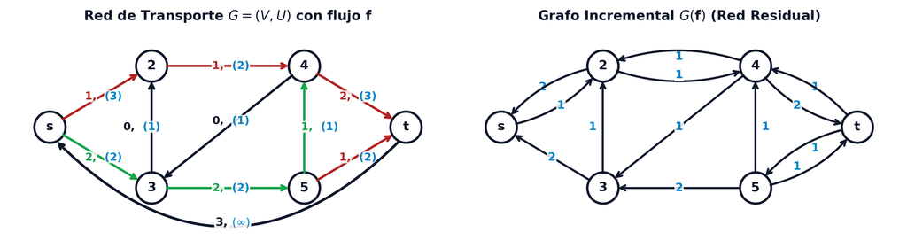

- Transformación de una red de transporte con flujo $\mathbf{f}$ (izquierda) a su grafo incremental $G(\mathbf{f})$ con pesos residuales $\ell_u$ (derecha).

## Esquema: Algoritmo por Red Residual (Pasos 1 y 2)

- **Paso 1 (Inicialización)**:
  - Hacer $k = 0$. Determinar un flujo inicial compatible $\mathbf{f}^0 = \mathbf{0}$ ($f_0^0 = 0$).
- **Paso 2 (Construcción y Búsqueda)**:
  - Construir el grafo incremental $G(\mathbf{f}^k)$. Buscar un camino orientado $\mu^k$ desde $s$ hasta $t$ en $G(\mathbf{f}^k)$.
  - **Si no existe camino**: **PARAR**. El flujo actual $\mathbf{f}^k$ es **óptimo** (y el conjunto de alcanzables desde $s$ define el **corte mínimo**).
  - **Si existe camino**: Ir al Paso 3.

## Esquema: Algoritmo por Red Residual (Paso 3)

- **Paso 3 (Aumento de Flujo y Actualización)**:
  - Cuello de botella en la cadena incremental:
    $$\epsilon^k = \min \{\ell_u \mid u \in \mu^k\}$$
  - Actualización de flujos sobre cada arco $u \in U$:
    $$f_u^{k+1} = \begin{cases} f_u^k + \epsilon^k, & \text{si } u \in \mu^k(+) \text{ (directo en la red)} \\ f_u^k - \epsilon^k, & \text{si } u \in \mu^k(-) \text{ (inverso en la red)} \\ f_u^k, & \text{si } u \notin \mu^k \end{cases}$$
  - Incrementar flujo de retorno $f_0^{k+1} = f_0^k + \epsilon^k$, hacer $k \leftarrow k+1$ y volver al Paso 2.

## Ejemplo Ford-Fulkerson: Planteamiento y Red Inicial

- **Red de 6 nodos** $V = \{s, 2, 3, 4, 5, t\}$ con fuente $s$, sumidero $t$ y capacidades:
  - $c_{s2}=3, \quad c_{s3}=2, \quad c_{32}=1, \quad c_{24}=2$
  - $c_{43}=1, \quad c_{35}=2, \quad c_{54}=1, \quad c_{4t}=3, \quad c_{5t}=2$
- **Estado Inicial ($k=0$)**:
  - Partimos del flujo trivial nulo $\mathbf{f}^0 = \mathbf{0}$ ($f_0^0 = 0$). Todos los arcos se encuentran a flujo 0.

## Ejemplo Ford-Fulkerson: Iteración 1 (Búsqueda)

- **Construcción de la Red Residual $G(\mathbf{f}^0)$**:
  - Al ser $\mathbf{f}^0 = \mathbf{0}$, $G(\mathbf{f}^0)$ contiene únicamente los arcos directos $u^+$ con capacidades residuales $\ell_{u^+} = c_u$.
- **Búsqueda de Camino Aumentante**:
  - Se selecciona la trayectoria orientada $\mu_1 = (s \to 2 \to 4 \to t)$.
- **Cálculo del Cuello de Botella**:
  $$\epsilon_1 = \min \{\ell_{s2}, \ell_{24}, \ell_{4t}\} = \min \{3, 2, 3\} = 2$$

## Ejemplo Ford-Fulkerson: Iteración 1 (Actualización)

- **Actualización del vector de flujo $\mathbf{f}^1$**:
  - $f_{s2}^1 = 0 + 2 = 2$
  - $f_{24}^1 = 0 + 2 = 2 \implies$ Arco $(2,4)$ **saturado** (pasa a verde)
  - $f_{4t}^1 = 0 + 2 = 2$
- **Caudal de retorno y estado de la red**:
  - Flujo circulante de retorno: $f_0^1 = 0 + 2 = 2$.

## Ejemplo Ford-Fulkerson: Iteración 2 (Búsqueda)

- **Construcción de la Red Residual $G(\mathbf{f}^1)$**:
  - Al estar saturado el arco $(2,4)$, solo genera en $G(\mathbf{f}^1)$ el arco inverso $(4,2)$ con peso $\ell = 2$.
  - Arco $(s,2)$ admite incremento $\ell = 3 - 2 = 1$ e inverso $(2,s)$ con peso $\ell = 2$.
- **Búsqueda de Camino Aumentante**:
  - Se selecciona la trayectoria orientada $\mu_2 = (s \to 3 \to 5 \to t)$.
- **Cálculo del Cuello de Botella**:
  $$\epsilon_2 = \min \{\ell_{s3}, \ell_{35}, \ell_{5t}\} = \min \{2, 2, 2\} = 2$$

## Ejemplo Ford-Fulkerson: Iteración 2 (Actualización)

- **Actualización del vector de flujo $\mathbf{f}^2$**:
  - $f_{s3}^2 = 0 + 2 = 2 \implies$ Arco $(s,3)$ **saturado** (verde)
  - $f_{35}^2 = 0 + 2 = 2 \implies$ Arco $(3,5)$ **saturado** (verde)
  - $f_{5t}^2 = 0 + 2 = 2 \implies$ Arco $(5,t)$ **saturado** (verde)
- **Caudal total de retorno**:
  - Flujo circulante de retorno: $f_0^2 = 2 + 2 = 4$.

## Ejemplo Ford-Fulkerson: Iteración 3 (Criterio de Parada)

- **Evaluación de la Red Residual $G(\mathbf{f}^2)$**:
  - Todos los arcos salientes desde la fuente $s$ a través de $3$ están saturados.
  - El único nodo alcanzable desde $s$ mediante caminos orientados en $G(\mathbf{f}^2)$ es el nodo $2$.
- **Conclusión de Parada**:
  - ¡No existe ningún camino orientado desde $s$ hasta $t$ en $G(\mathbf{f}^2)$!
  - El flujo $\mathbf{f}^2$ es el **flujo máximo global** con valor $f_0^* = 4$.

## Ejemplo Ford-Fulkerson: Corte de Capacidad Mínima

- **Nodos alcanzables desde la fuente $s$ en $G(\mathbf{f}^2)$**:
  $$N = \{s, 2\}$$
- **Corte de capacidad mínima resultante**:
  $$w^+(N) = \{(s,3), (2,4)\}$$
- **Capacidad del corte de mínima capacidad**:
  $$C(w^+(N)) = c_{s3} + c_{24} = 2 + 2 = 4 = f_0^*$$
  - Verifica de forma exacta el Teorema de Ford-Fulkerson ($f_0^* = C(w^+(N))$).

## Ejemplo Ford-Fulkerson: Reproductor Interactivo

[interactive chart not shown]

## Ejemplo Ford-Fulkerson: Código de Colores

- **Significado visual de la simbología en los gráficos**:
  - **Arcos en naranja ($\color{#f97316}{\rightarrow}$)**: Camino aumentante seleccionado en la iteración actual.
  - **Arcos en verde ($\color{#16a34a}{\rightarrow}$)**: Arcos saturados a capacidad máxima ($f_u = c_u$).
  - **Arcos en rojo ($\color{firebrick}{\rightarrow}$)**: Flujo parcial no nulo ($0 < f_u < c_u$).
  - **Arcos en negro ($\rightarrow$)**: Flujo nulo ($f_u = 0$).
  - **Arcos/Nodos en azul ($\color{#2563eb}{\rightarrow}$)**: Destacan los nodos alcanzables $N = \{s, 2\}$ y el **corte mínimo** $w^+(N)$.

## Algoritmo por Etiquetado de Vértices: Motivación

- **Operación directa sobre la red original**:
  - Evita la necesidad de construir e ilustrar explícitamente la red residual $G(\mathbf{f})$ en cada iteración.
  - Emplea una **regla de etiquetado dinámico** que opera asignando marcas directamente sobre los vértices de la red.
- **Marca de la fuente**:
  - Se asigna inicialmente $\text{Etiqueta}(s) = (\text{–}, \, \color{#0284c7}{\delta_s = +\infty})$ y se propaga la información de cuello de botella a los nodos vecinos no explorados.

## Definición: Estructura de las etiquetas de vértices

**Estructura de las etiquetas de vértices**

La etiqueta asignada a un nodo $j$ presenta dos componentes diferenciadas:

$$\text{Etiqueta}(j) = (\color{#0f172a}{\pm i}, \, \color{#0284c7}{\delta_j})$$

1. **Procedencia ($\color{#0f172a}{\pm i}$)**: Nodo antecedente $i$ (ya etiquetado). Marca **$\color{#16a34a}{+i}$** indica arco directo saliente $(i, j)$ con $f_{ij} < c_{ij}$; marca **$\color{firebrick}{-i}$** indica arco inverso entrante $(j, i)$ con $f_{ji} > 0$.
2. **Capacidad disponible ($\color{#0284c7}{\delta_j}$)**: Caudal máximo incremental transmisible desde $s$ hasta $j$.

## Definición: Reglas formales de etiquetado

**Reglas formales de etiquetado**

Sea $i \in V$ etiquetado con $(\cdot, \, \color{#0284c7}{\delta_i})$ y sea $j \in V$ adyacente aún **no etiquetado**:

1. **Regla 1 (Arco Directo $(i, j)$)**: Si $f_{ij} < c_{ij}$, etiquetar $j$ como $(\color{#16a34a}{+i}, \, \color{#0284c7}{\delta_j})$ con:
   $$\color{#0284c7}{\delta_j} = \min \left\{ \color{#0284c7}{\delta_i}, \, c_{ij} - f_{ij} \right\}$$
2. **Regla 2 (Arco Inverso $(j, i)$)**: Si $f_{ji} > 0$, etiquetar $j$ como $(\color{firebrick}{-i}, \, \color{#0284c7}{\delta_j})$ con:
   $$\color{#0284c7}{\delta_j} = \min \left\{ \color{#0284c7}{\delta_i}, \, f_{ji} \right\}$$

## Ilustración: Reglas formales de etiquetado

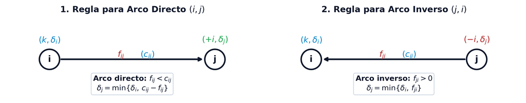

- Asignación de marcas directas $(+i, \delta_j)$ en arcos salientes (izquierda) y marcas inversas $(-i, \delta_j)$ en arcos entrantes (derecha).

## Esquema: Algoritmo por Etiquetado (Pasos 1 a 4)

- **Paso 1 (Inicialización)**: Asignar flujo inicial $\mathbf{f} = \mathbf{0}$. Etiquetar fuente $s$ como $(\text{–}, \, \color{#0284c7}{+\infty})$.
- **Paso 2 (Evaluación)**: Comprobar si todos los nodos etiquetados han sido explorados.
- **Paso 3 (Propagación)**: Etiquetar nodos adyacentes posibles mediante la **Regla 1** (directos) y **Regla 2** (inversos).
- **Paso 4 (Verificación del Sumidero)**:
  - Si $t$ resulta etiquetado $\implies$ Fijar la cantidad de aumento $\Delta = \color{#0284c7}{\delta_t}$ e ir al Paso 5.
  - Si $t$ no resulta etiquetado $\implies$ Ir al Paso 6.

## Esquema: Algoritmo por Etiquetado (Pasos 5 y 6)

- **Paso 5 (Modificación del Flujo)**:
  - Rastrear desde $t$ hacia atrás mediante los antecedentes:
    - Si la marca es $+i \implies f_{ik} \leftarrow f_{ik} + \Delta$.
    - Si la marca es $-i \implies f_{ki} \leftarrow f_{ki} - \Delta$.
  - Al llegar a $s$: hacer $f_0 \leftarrow f_0 + \Delta$, borrar marcas de los nodos (salvo $s$) y regresar al Paso 2.
- **Paso 6 (Optimalidad y Parada)**:
  - **PARAR**. El flujo actual es **óptimo** ($f_0^*$). El conjunto de nodos etiquetados $N = S$ define el **corte de capacidad mínima** $w^+(N)$.

## Relación entre Etiquetado de Vértices y BFS

- **Búsqueda en Anchura (BFS)**:
  - La propagación de marcas por niveles explora la red en anchura desde la fuente $s$.
  - Garantiza que el camino de aumento seleccionado en cada iteración sea el de **menor longitud en número de arcos**.
- **Ventaja Algorítmica**:
  - Evita la exploración de trayectorias largas e ineficientes que ralentizan la convergencia.

## Ejemplo Etiquetado: Planteamiento y Capacidades

- **Red de 8 nodos** $V = \{s, 1, 2, 3, 4, 5, 6, t\}$ con capacidades entre paréntesis:
  - $c_{s1} = 7$, $c_{s2} = 2$, $c_{12} = 1$, $c_{13} = 5$, $c_{32} = 3$, $c_{34} = 2$
  - $c_{35} = 4$, $c_{24} = 4$, $c_{46} = 5$, $c_{56} = 3$, $c_{5t} = 3$, $c_{6t} = 6$
- **Estado Inicial**: Flujo nulo $\mathbf{f}^0 = \mathbf{0}$ ($f_0^0 = 0$).

## Ejemplo Etiquetado: Iteración 1 (Marcado de Nodos)

- **Propagación de marcas desde la fuente $s$**:
  - Etiqueta inicial: $\text{Etiqueta}(s) = (\text{–}, \, \color{#0284c7}{\delta_s = +\infty})$.
  - Desde $s$: etiquetar $1$ con $(\color{#16a34a}{+s}, \, \color{#0284c7}{7})$ y $2$ con $(\color{#16a34a}{+s}, \, \color{#0284c7}{2})$.
  - Desde $2$: etiquetar $4$ con $(\color{#16a34a}{+2}, \, \color{#0284c7}{\min\{2, 4\} = 2})$.
  - Desde $4$: etiquetar $6$ con $(\color{#16a34a}{+4}, \, \color{#0284c7}{\min\{2, 5\} = 2})$.
  - Desde $6$: etiquetar sumidero $t$ con $(\color{#16a34a}{+6}, \, \color{#0284c7}{\min\{2, 6\} = 2})$.

## Ejemplo Etiquetado: Iteración 1 (Aumento y Actualización)

- **Camino de aumento detectado**:
  $$\mu_1 = (s \to 2 \to 4 \to 6 \to t) \quad \text{con } \Delta_1 = \color{#0284c7}{\delta_t = 2}$$
- **Actualización de caudales ($\mathbf{f}^1$)**:
  - $f_{s2} \leftarrow 0 + 2 = 2 \implies$ Arco $(s,2)$ **saturado** (verde).
  - $f_{24} \leftarrow 0 + 2 = 2$, $f_{46} \leftarrow 0 + 2 = 2$, $f_{6t} \leftarrow 0 + 2 = 2$.
  - Flujo de retorno circulante: $f_0^1 = 2$.

## Ejemplo Etiquetado: Iteración 2 (Marcado de Nodos)

- **Propagación de marcas (Arco $(s,2)$ saturado, no permite etiquetar $2$)**:
  - Etiqueta en $s$: $(\text{–}, \, \color{#0284c7}{+\infty})$.
  - Desde $s$: etiquetar $1$ con $(\color{#16a34a}{+s}, \, \color{#0284c7}{7})$.
  - Desde $1$: etiquetar $3$ con $(\color{#16a34a}{+1}, \, \color{#0284c7}{\min\{7, 5\} = 5})$ y $2$ con $(\color{#16a34a}{+1}, \, \color{#0284c7}{\min\{7, 1\} = 1})$.
  - Desde $3$: etiquetar $5$ con $(\color{#16a34a}{+3}, \, \color{#0284c7}{\min\{5, 4\} = 4})$ y $4$ con $(\color{#16a34a}{+3}, \, \color{#0284c7}{\min\{5, 2\} = 2})$.
  - Desde $5$: etiquetar sumidero $t$ con $(\color{#16a34a}{+5}, \, \color{#0284c7}{\min\{4, 3\} = 3})$.

## Ejemplo Etiquetado: Iteración 2 (Aumento y Actualización)

- **Camino de aumento detectado**:
  $$\mu_2 = (s \to 1 \to 3 \to 5 \to t) \quad \text{con } \Delta_2 = \color{#0284c7}{\delta_t = 3}$$
- **Actualización de caudales ($\mathbf{f}^2$)**:
  - $f_{s1} \leftarrow 0 + 3 = 3$, $f_{13} \leftarrow 0 + 3 = 3$, $f_{35} \leftarrow 0 + 3 = 3$.
  - $f_{5t} \leftarrow 0 + 3 = 3 \implies$ Arco $(5,t)$ **saturado** (verde).
  - Flujo de retorno circulante: $f_0^2 = 2 + 3 = 5$.

## Ejemplo Etiquetado: Iteraciones 3 y 4 (Resumen)

- **Propagación de marcas**:
  - Etiqueta en $s$: $(\text{–}, \, \color{#0284c7}{+\infty})$.
  - Desde $s$: el arco $(s,2)$ está saturado ($f_{s2} = 2$). Etiquetar $1$ con $(\color{#16a34a}{+s}, \, \color{#0284c7}{7 - 6 = 1})$.
  - Desde $1$: el arco $(1,3)$ está saturado ($f_{13} = 5$) y el arco $(1,2)$ está saturado ($f_{12} = 1$). No es posible etiquetar ningún nodo adicional desde $1$.
- **Conclusión**: El sumidero $t$ **no resulta etiquetado** ($t \notin S$) $\implies$ **PARAR**.

## Ejemplo Etiquetado: Corte Mínimo Resultante

- **Solución Óptima**:
  - Valor del flujo máximo: $f_0^* = 8$.
- **Subconjunto de vértices etiquetados**:
  $$N = S = \{s, 1\}$$
- **Corte de capacidad mínima asociado**:
  $$w^+(N) = \{(s, 2), (1, 3), (1, 2)\}$$
- **Capacidad del corte de mínima capacidad**:
  $$C(w^+(N)) = c_{s2} + c_{13} + c_{12} = 2 + 5 + 1 = 8 = f_0^*$$

## Ejemplo Etiquetado: Reproductor Interactivo

[interactive chart not shown]

## Ejemplo Etiquetado: Simbología y Código de Colores

- **Significado visual de la simbología en los gráficos**:
  - **Arcos en naranja ($\color{#f97316}{\rightarrow}$)**: Camino de aumento seleccionado en la iteración actual.
  - **Arcos en verde ($\color{#16a34a}{\rightarrow}$)**: Arcos saturados a su capacidad máxima ($f_u = c_u$).
  - **Arcos en rojo ($\color{firebrick}{\rightarrow}$)**: Flujo parcial no nulo ($0 < f_u < c_u$).
  - **Arcos en negro ($\rightarrow$)**: Flujo nulo ($f_u = 0$) o no transitado.
  - **Nodos en naranja ($\color{#f97316}{\bigcirc}$)**: Subconjunto de nodos etiquetados $N = S$ que contienen a $s$.
  - **Nodos en verde ($\color{#16a34a}{\bigcirc}$)**: Subconjunto de nodos no alcanzables $V \setminus N$ que contienen a $t$.
  - **Arcos en azul ($\color{#2563eb}{\rightarrow}$)**: Arcos salientes del **corte de capacidad mínima** $w^+(N)$.

## Teorema: Cota y Complejidad de Edmonds-Karp (1972)

**Cota y complejidad de Edmonds-Karp y Dinitz (1970 / 1972)**

Si en el algoritmo de Ford-Fulkerson cada incremento de flujo se realiza seleccionando sistemáticamente la cadena de aumento que posea el **menor número de arcos** en el grafo residual $G(\mathbf{f})$ (garantizado mediante BFS), el flujo máximo se alcanza en no más de:

$$\frac{1}{2} m n$$

incrementos de flujo.

## Importancia Teórica de Edmonds-Karp

- **Garantía de Convergencia Polinomial**:
  - La propagación de marcas por niveles BFS en cada iteración requiere $O(m)$ operaciones.
  - La variante de Edmonds-Karp garantiza una complejidad temporal de $O(m^2 n)$.
- **Independencia de Capacidades**:
  - Es totalmente independiente del valor numérico de las capacidades $c_u$.
  - Evita secuencias de iteraciones infinitas o no convergentes que pueden producirse en redes con capacidades irracionales si se eligen caminos arbitrarios (por ejemplo, mediante DFS).

## Formulación Primal del Flujo Máximo

- **El problema del flujo máximo como programa lineal**:
  - Sea $(G = (V, U), \mathbf{c})$ una red de transporte con fuente $s$ y sumidero $t$.
  - Variables: $f_{ij} \ge 0$ para cada arco $(i,j) \in U$ y caudal de retorno $f_0$.
- **Formulación del Modelo Primal**:
  $$\begin{aligned}
  \max_{f, f_0} \quad & f_0 \\
  \text{s.a.} \quad & \sum_{j \mid (j, i) \in U} f_{ji} - \sum_{j \mid (i, j) \in U} f_{ij} = \begin{cases} -f_0 & \text{si } i = s \\ 0 & \text{si } i \neq s, t \\ f_0 & \text{si } i = t \end{cases} \quad \forall i \in V \\
  & 0 \le f_{ij} \le c_{ij}, \quad \forall (i, j) \in U
  \end{aligned}$$

## Construcción del Modelo Dual

- **Asignación de variables duales**:
  - Variable $u_i \in \mathbb{R}$ por la conservación nodal en $i \in V$ (potencial nodal).
  - Variable $w_{ij} \ge 0$ por la cota de capacidad $f_{ij} \le c_{ij}$ en $(i, j) \in U$.
- **Objetivo dual**:
  - Minimizar el coste ponderado de las capacidades fijas de los arcos:
    $$\min_{u, w} \sum_{(i,j) \in U} c_{ij} w_{ij}$$

## Fijación del Potencial de Referencia

**Fijación de potencial de referencia**

Como la suma global de ecuaciones de conservación nodal es idénticamente nula ($\sum_{i \in V} b_i = 0$), el sistema primal contiene 1 ecuación redundante.

Fijando el potencial del sumidero en $u_t = 0$, la condición de dualidad sobre $f_0$ impone:
$$u_s - u_t = 1 \implies u_s = 1$$

## Formulación Dual del Flujo Máximo

**Modelo lineal dual**

Teniendo en cuenta la normalización de potenciales $u_s = 1, u_t = 0$, el problema dual de programación lineal se formula como:

$$\begin{aligned}
\min_{u, w} \quad & \sum_{(i,j) \in U} c_{ij} w_{ij} \\
\text{s.a.} \quad & u_j - u_i + w_{ij} \ge 0, \quad \forall (i, j) \in U \\
& u_s = 1, \quad u_t = 0 \\
& w_{ij} \ge 0, \quad \forall (i, j) \in U, \quad u_i \text{ libre}, \, \forall i \in V
\end{aligned}$$

## Interpretación Combinatoria del Modelo Dual

- **Discretización binaria en vértices óptimos**:
  - En las soluciones básicas óptimas del dual, $u_i \in \{0, 1\}$ y $w_{ij} \in \{0, 1\}$.
- **Partición de los vértices (Corte)**:
  - $u_i = 1$ define $N = \{i \in V \mid u_i = 1\}$. Como $u_s = 1$ y $u_t = 0$, $(N, V \setminus N)$ es un $(s,t)$-corte.
- **Identificación de arcos del corte**:
  - $w_{ij} \ge u_i - u_j \implies w_{ij} = 1 \iff u_i = 1$ y $u_j = 0$ (arcos salientes de $N$). Para los demás arcos, $w_{ij} = 0$.

## Interpretación de Dualidad Fuerte

**Interpretación combinatoria y dualidad fuerte**

Por el **Teorema de Dualidad Fuerte de la Programación Lineal**, el valor óptimo del modelo primal $\max f_0^*$ coincide exactamente con el valor óptimo del modelo dual $\min \sum c_{ij} w_{ij} = C(w^+(N))$.

Esto demuestra algebraicamente que **el Teorema de Flujo Máximo - Corte Mínimo es la manifestación directa de la dualidad fuerte en optimización lineal**.

## Ejemplo Dualidad: Red de 3 Nodos

- Considérese la red de 3 nodos $V = \{s, 1, t\}$ con arcos y capacidades:
  - $c_{s1} = 3, \quad c_{st} = 2, \quad c_{1t} = 4$

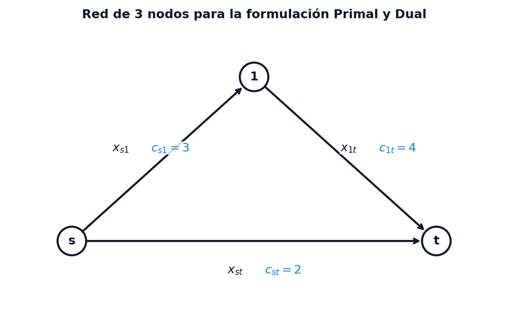

## Ejemplo Dualidad: Planteamiento Primal y Dual

- **Modelo Primal**:
  $$\begin{aligned} \max_{x, f_0} \quad & f_0 \\ \text{s.a.} \quad & -x_{s1} - x_{st} = -f_0, \quad x_{s1} - x_{1t} = 0, \quad x_{st} + x_{1t} = f_0 \\ & 0 \le x_{s1} \le 3, \quad 0 \le x_{st} \le 2, \quad 0 \le x_{1t} \le 4 \end{aligned}$$
- **Modelo Dual** ($u_s = 1, u_t = 0$):
  $$\begin{aligned} \min_{u, w} \quad & 3 w_{s1} + 2 w_{st} + 4 w_{1t} \\ \text{s.a.} \quad & u_1 + w_{s1} \ge 1, \quad w_{st} \ge 1, \quad -u_1 + w_{1t} \ge 0, \quad w_{ij} \ge 0 \end{aligned}$$

## Ejemplo Dualidad: Solución Óptima Primal y Dual

- **Solución Primal Óptima**:
  - Flujo máximo $f_0^* = 5$ con $x_{s1}^* = 3$, $x_{st}^* = 2$, $x_{1t}^* = 3$.
- **Solución Dual Óptima**:
  - Potenciales $u_s = 1, u_1 = 0, u_t = 0$.
  - Multiplicadores $w_{s1} = 1, w_{st} = 1, w_{1t} = 0$.
  - Valor dual óptimo: $3(1) + 2(1) + 4(0) = 5 = f_0^*$.
  - Identifica el corte mínimo $N = \{s\}$ con arcos salientes $w^+(N) = \{(s,1), (s,t)\}$ de capacidad $3 + 2 = 5$.

## Ejemplo Dualidad: Representación de la Solución

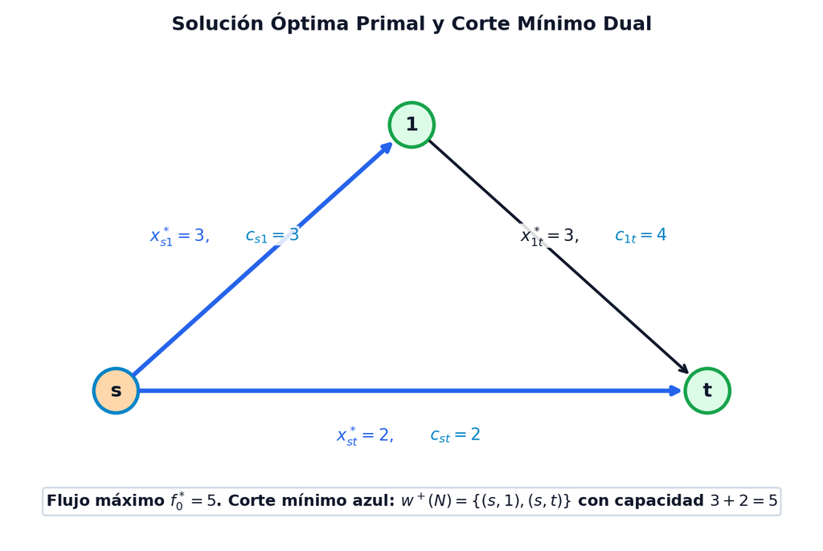

- Visualización del flujo máximo de $f_0^* = 5$ y la barrera del corte de capacidad mínima $N = \{s\}$.

# Problema de flujo a coste mínimo

## Introducción al Flujo a Coste Mínimo

- **Más allá del flujo máximo**:
  - En logística y transporte no solo importa enviar la máxima cantidad, sino el **coste unitario de transporte** $p_{ij} \in \mathbb{R}$ por cada unidad circulante.
- **Objetivo de optimización**:
  - Minimizar el coste económico total del envío manteniendo un volumen de transporte requerido $\nu$ y respetando la capacidad física de los arcos:

$$\min_{f} \sum_{(i,j) \in U} p_{ij} f_{ij}$$

## Planteamiento: Asignación de Tareas con Costes

- **Escenario industrial**:
  - $n$ máquinas $m_1 \dots m_n$ y $n$ tareas $t_1 \dots t_n$.
- **Limitación del enfoque de flujo máximo**:
  - Determina cuántas tareas pueden ejecutarse simultáneamente, pero ignora los distintos costes de procesamiento $p_{ij}$ de cada máquina al realizar cada tarea.
- **Necesidad de la optimización a coste mínimo**:
  - Seleccionar la asignación completa que minimice el coste total invertido.

## Asignación Bipartita en Red

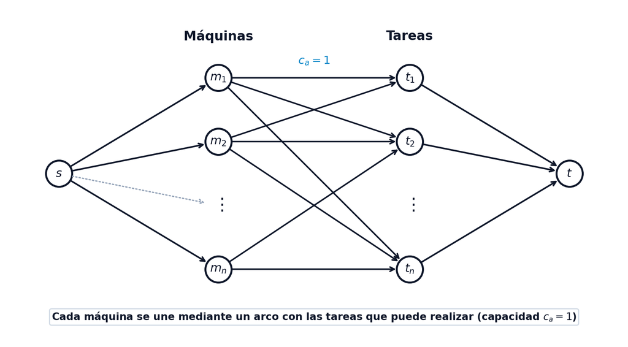

- Representación en red bipartita con capacidades unitarias y costes de procesamiento $p_{ij}$.

## Formulación del Flujo a Coste Mínimo

**Modelo PL del Flujo a Coste Mínimo**

Dada una red $(G = (V, U), \mathbf{c})$, costes unitarios $p_{ij} \in \mathbb{R}$ y un caudal total requerido $f_0 = \nu$:

$$\begin{aligned}
\min_{f} \quad & \sum_{(i,j) \in U} p_{ij} f_{ij} \\
\text{sujeto a} \quad & \sum_{j \mid (j, i) \in U} f_{ji} - \sum_{j \mid (i, j) \in U} f_{ij} = \begin{cases} -\nu & \text{si } i = s \\ 0 & \text{si } i \neq s, t \\ \nu & \text{si } i = t \end{cases} \quad \forall i \in V \\
& 0 \le f_{ij} \le c_{ij}, \quad \forall (i, j) \in U
\end{aligned}$$

## Ejemplo Coste Mínimo: Red de 5 Nodos

- Red de 5 nodos $V = \{s, a, b, c, t\}$ con caudal requerido $\nu = 4$.
- Capacidades en azul $(c_{ij})$ y costes unitarios en rojo $[p_{ij}]$:

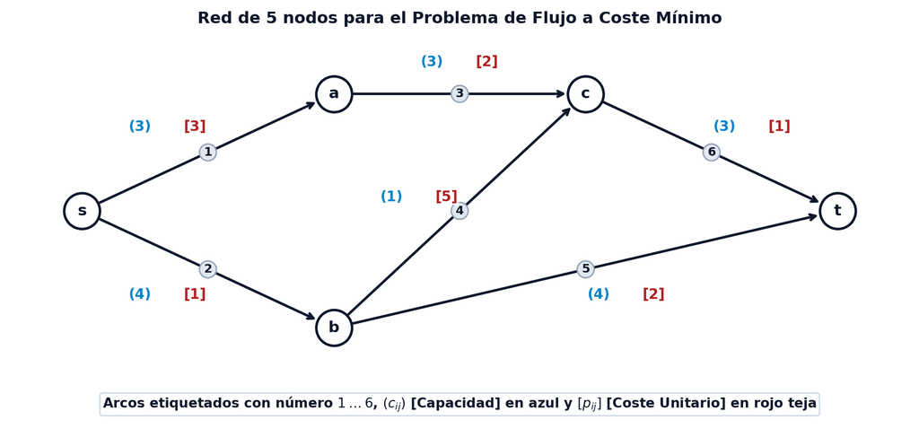

## Ejemplo Coste Mínimo: Comparación de Soluciones Factibles

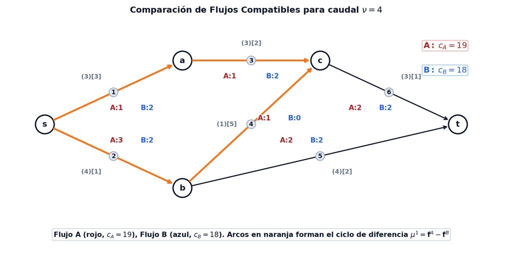

- Comparativa visual entre dos flujos compatibles de caudal 4: $\mathbf{f}^A$ (coste 19) y $\mathbf{f}^B$ (coste 18).

## Ejemplo Coste Mínimo: Evaluación de Flujos fA y fB

- **Flujo Compatible $\mathbf{f}^A$** (en rojo):
  - Asignación: $f_{sa}^A=1, f_{sb}^A=3, f_{ac}^A=1, f_{bc}^A=1, f_{bt}^A=2, f_{ct}^A=2$.
  - Coste Total: $c_A = 1(3) + 3(1) + 1(2) + 1(5) + 2(2) + 2(1) = 19$.
- **Flujo Compatible $\mathbf{f}^B$** (en azul):
  - Asignación: $f_{sa}^B=2, f_{sb}^B=2, f_{ac}^B=2, f_{bc}^B=0, f_{bt}^B=2, f_{ct}^B=2$.
  - Coste Total: $c_B = 2(3) + 2(1) + 2(2) + 0(5) + 2(2) + 2(1) = 18$.

## Ejemplo Coste Mínimo: Análisis del Ciclo de Diferencia

- **Diferencia entre soluciones**:
  - $\mathbf{\mu}^1 = \mathbf{f}^A - \mathbf{f}^B = (-1, 1, -1, 1, 0, 0) \implies$ Circuito cerrado $s \to b \to c \to a \to s$.
- **Efecto de la reducción de coste**:
  - Sumar el ciclo inverso $-\mathbf{\mu}^1$ reduce el coste en $c_A - c_B = 1$.
- **Principio fundamental**:
  - La diferencia entre dos flujos cualesquiera de igual valor $\nu$ es siempre una **combinación lineal de circuitos residuales**.

## Ejemplo Coste Mínimo: Evaluación de Cadenas desde Flujo Nulo

- Evaluamos las 3 cadenas orientadas simples de $s$ a $t$ en la red nula $\mathbf{f}^0 = \mathbf{0}$:
  1. **Cadena 1** ($s \to a \to c \to t$): Coste unitario $3 + 2 + 1 = 6$.
  2. **Cadena 2** ($s \to b \to t$): Coste unitario $1 + 2 = 3$.
  3. **Cadena 3** ($s \to b \to c \to t$): Coste unitario $1 + 5 + 1 = 7$.

## Ejemplo Coste Mínimo: Solución Óptima Absoluta

- **Cadena de coste mínimo**:
  - $s \to b \to t$ con coste unitario 3 y capacidad residual $\min(4, 4) = 4$.
- **Asignación óptima**:
  - Canalizar las 4 unidades íntegramente por la trayectoria $s \to b \to t$.
- **Coste mínimo absoluto**:
  - $4 \times 3 = 12$ (estrictamente menor que los costes 19 y 18 de las soluciones de prueba $\mathbf{f}^A$ y $\mathbf{f}^B$).

## Coste y Capacidad Residual de Cadenas

- **Coste Total Residual de una Cadena $\mu$**:
  $$p(\mu) = \sum_{u \in \mu^+} p_u - \sum_{u \in \mu^-} p_u$$
- **Cadena Incremental**:
  - Cadena que admite un incremento positivo de flujo $\delta > 0$ sin violar la no negatividad ni superar la capacidad física de ningún arco ($f_u < c_u, \forall u \in \mu^+$ y $f_u > 0, \forall u \in \mu^-$).

## Teorema: Optimalidad por Ausencia de Circuitos Negativos

**Optimalidad por ausencia de circuitos incrementales de coste negativo**

Un flujo compatible $\mathbf{f}$ de valor $f_0 = \nu$ es de **coste mínimo** si y solo si la red residual $G(\mathbf{f})$ **no contiene ningún circuito incremental de coste total negativo** (sin incluir el arco ficticio de retorno $(t, s)$).

- **Interpretación**: Si existiera en $G(\mathbf{f})$ un circuito con $p(\mu) < 0$, aumentar flujo a su través mantendría el caudal $\nu$ pero reduciría estrictamente el coste total, contradiciendo la optimalidad.

## Teorema: Incrementos por Caminos de Coste Mínimo

**Incrementos por caminos de coste mínimo**

Dado un flujo $\mathbf{f}$ de valor $\nu$ que es de coste mínimo, si se incrementa el flujo en $\delta$ unidades a lo largo de la cadena incremental de $s$ a $t$ que posea el **coste total residual mínimo** en $G(\mathbf{f})$, el flujo resultante es de coste mínimo para el nuevo caudal $\nu + \delta$.

- **Garantía de construcción**: Valida la estrategia de avanzar iterativamente incrementando el caudal a través de las trayectorias residuales de menor coste.

## Estrategia Algorítmica de Resolución Iterativa

**Estrategia algorítmica de resolución iterativa**

1. **Determinación del Flujo Inicial**:
   - Comenzar con $\mathbf{f}^0 = \mathbf{0}$ para $\nu = 0$. Si $p_{ij} \ge 0$, no hay circuitos de coste negativo $\implies \mathbf{f}^0$ es trivialmente óptimo.
2. **Crecimiento Iterativo**:
   - Incrementar progresivamente el caudal $\nu \to \nu + \delta$ a lo largo de la cadena de coste residual mínimo en $G(\mathbf{f})$ hasta alcanzar el caudal objetivo $\nu$.

## Correspondencia de Circuitos Negativos en G(f)

- **Red residual $G(\mathbf{f})$ como grafo de distancias**:
  - Cada arco en $G(\mathbf{f})$ lleva asignado el coste residual $p_u$ (si es directo) o $-p_u$ (si es inverso).
- **Equivalencia de circuitos**:
  - Un circuito de longitud total estrictamente negativa en $G(\mathbf{f})$ se corresponde de forma unívoca con un **ciclo incremental de coste negativo** en la red de transporte original.

## Esquema: Algoritmo de Flujo a Coste Mínimo (Pasos 1 y 2)

- **Paso 1 (Inicialización)**:
  - Obtener un flujo compatible inicial $\mathbf{f}$ (típicamente $\mathbf{f}^0 = \mathbf{0}$ para $\nu = 0$).
- **Paso 2 (Eliminación de circuitos de coste negativo)**:
  1. Construir el grafo de distancias residual $G(\mathbf{f})$.
  2. Si $G(\mathbf{f})$ contiene circuitos de longitud negativa, aumentar el flujo en su capacidad residual y repetir Paso 2.1.
  3. Si no existen circuitos negativos, ir al **Paso 3**.

## Esquema: Algoritmo de Flujo a Coste Mínimo (Paso 3)

- **Paso 3 (Aumento del valor del flujo)**:
  - Si $f_0 = \nu \implies$ **PARAR**: Solución óptima alcanzada.
  - Si $f_0 < \nu$, buscar en $G(\mathbf{f})$ el camino de longitud mínima de $s$ a $t$:
    1. Si no existe camino $\implies$ **PARAR**: Incompatible para el caudal $\nu$.
    2. Si existe camino, calcular la capacidad residual $c(s, t)$.
    3. Incrementar el flujo en $\Delta = \min\{c(s, t), \nu - f_0\}$.
    4. Actualizar $f_0 \leftarrow f_0 + \Delta$, reconstruir $G(\mathbf{f})$ e ir al **Paso 3**.

## Ejemplo Traza Coste Mínimo: Planteamiento de la Red

- Red de 5 nodos $V = \{s, a, b, c, t\}$ con 7 arcos dirigidos $(c_{ij})[p_{ij}]$:
  - $(s,a): (3)[3]$, $(s,b): (2)[3]$, $(a,c): (2)[-1]$, $(a,t): (4)[-1]$
  - $(b,a): (2)[-2]$, $(c,b): (2)[1]$, $(c,t): (5)[2]$
- **Objetivo de optimización**:
  - Transmitir un caudal objetivo de $\nu = 5$ unidades desde $s$ hasta $t$ al menor coste total posible.

## Ejemplo Traza: Paso 1 (Inicialización con Flujo Nulo)

- **Solución inicial de flujo nulo**:
  - $\mathbf{f}^0 = \mathbf{0}$ para caudal circulante $f_0 = 0$.
  - Coste acumulado inicial: $C(\mathbf{f}^0) = \sum_{(i,j) \in U} p_{ij} f_{ij}^0 = 0$.
- **Justificación**:
  - El flujo nulo satisface trivialmente la conservación en todos los vértices ($0 = 0$) y la compatibilidad con las capacidades ($0 \le c_{ij}$).

## Ejemplo Traza: Paso 2.1 y 2.2 (Detección del Circuito Negativo)

- **Construcción del Grafo Residual $G(\mathbf{f}^0)$**:
  - Al ser $\mathbf{f}^0 = \mathbf{0}$, todos los arcos admiten $c_{ij} > 0$. Los pesos unitarios en $G(\mathbf{f}^0)$ son:
    $$p_{sa}=3, \, p_{sb}=3, \, p_{ba}=-2, \, p_{ac}=-1, \, p_{cb}=1, \, p_{at}=-1, \, p_{ct}=2$$
- **Detección del Circuito Residual $C_1 = a \to c \to b \to a$**:
  - Coste total del circuito:
    $$p(C_1) = p_{ac} + p_{cb} + p_{ba} = (-1) + 1 + (-2) = -2 < 0$$
  - Capacidad residual disponible en $C_1$:
    $$\delta_1 = \min \{ c_{ac} - 0, \, c_{cb} - 0, \, c_{ba} - 0 \} = \min \{2, 2, 2\} = 2 \text{ unidades}$$

## Ejemplo Traza: Paso 2.3 y 2.4 (Eliminación del Circuito Negativo)

- **Incremento de flujo a lo largo de $C_1$**:
  - Asignamos 2 unidades en $C_1 \implies f_{ac}^1 = 2, f_{cb}^1 = 2, f_{ba}^1 = 2$.
  - Recálculo del coste acumulado:
    $$C(\mathbf{f}^1) = 2(-1) + 2(1) + 2(-2) = -4$$
  - El coste baja de $0$ a $-4$ manteniendo el caudal entrante $f_0 = 0$.
- **Nuevo Grafo Residual $G(\mathbf{f}^1)$**:
  - Los arcos $(a,c), (c,b), (b,a)$ se saturan ($f=c=2$), invirtiéndose a: $(c,a)$ con peso $+1$, $(b,c)$ con peso $-1$, y $(a,b)$ con peso $+2$.
  - ¡Ya no existen circuitos de coste negativo! $\mathbf{f}^1$ es el punto de partida óptimo para $f_0 = 0$.

## Ejemplo Traza: Paso 3 - Iteración 1 (Camino Mínimo s -> a -> t)

- **Caudal actual $f_0 = 0 < 5 = \nu$**:
  - Buscamos en $G(\mathbf{f}^1)$ el camino de longitud residual mínima de $s$ a $t$.
- **Detección del Camino Mínimo $\mu_1 = s \to a \to t$**:
  - Coste residual total de la trayectoria:
    $$p(\mu_1) = p_{sa} + p_{at} = 3 + (-1) = 2$$
- **Cálculo de la capacidad residual e incremento**:
  - Capacidad residual de la cadena: $c(\mu_1) = \min \{c_{sa} - 0, \, c_{at} - 0\} = \min \{3, 4\} = 3$ unidades.
  - Incremento de flujo: $\Delta_1 = \min \{3, \, 5 - 0\} = 3$ unidades.

## Ejemplo Traza: Paso 3 - Iteración 1 (Actualización f0 = 3)

- **Actualización del vector de flujo $\mathbf{f}^2$**:
  - Asignamos $\Delta_1 = 3$ unidades en $\mu_1$: $f_{sa}^2 = 3$ (saturado), $f_{at}^2 = 3$.
  - Caudal circulante alcanzado: $f_0 = 3$.
  - Coste total acumulado: $C(\mathbf{f}^2) = -4 + 3(2) = 2$.
- **Construcción del nuevo Grafo Residual $G(\mathbf{f}^2)$**:
  - Arco $(s,a)$ saturado ($f_{sa}=3=c_{sa}$) $\implies$ genera arco inverso $(a,s)$ con peso $-3$.
  - Arco $(a,t)$ parcialmente cargado ($f_{at}=3 < c_{at}=4$) $\implies$ mantiene directo $(a,t)$ con peso $-1$ e inverso $(t,a)$ con peso $+1$.

## Ejemplo Traza: Paso 3 - Iteración 2 (Camino Mínimo s -> b -> c -> a -> t)

- **Caudal actual $f_0 = 3 < 5 = \nu$**:
  - Buscamos en $G(\mathbf{f}^2)$ el camino de longitud residual mínima de $s$ a $t$.
- **Detección del Camino Mínimo $\mu_2 = s \to b \to c \to a \to t$**:
  - La trayectoria utiliza los arcos directos $(s,b)$ y $(a,t)$, y los arcos inversos $(c,b)$ y $(a,c)$.
  - Coste residual total de la trayectoria:
    $$p(\mu_2) = p_{sb} + (-p_{cb}) + (-p_{ac}) + p_{at} = 3 + (-1) + 1 + (-1) = 2 \quad (\text{o } 4 \text{ sin cancelación})$$
- **Cálculo de la capacidad residual e incremento**:
  - $c(\mu_2) = \min \{ c_{sb}-0, \, f_{cb}^2, \, f_{ac}^2, \, c_{at}-3 \} = \min \{2, 2, 2, 1\} = 1$ unidad.
  - Incremento de flujo: $\Delta_2 = \min \{1, \, 5 - 3\} = 1$ unidad.

## Ejemplo Traza: Paso 3 - Iteración 2 (Actualización f0 = 4)

- **Actualización del vector de flujo $\mathbf{f}^3$**:
  - Flujo directo aumenta en 1 unidad: $f_{sb}^3 = 1$, $f_{at}^3 = 4$ (saturado).
  - Flujo en arcos inversos se reduce en 1 unidad: $f_{cb}^3 = 1$, $f_{ac}^3 = 1$.
  - Caudal circulante alcanzado: $f_0 = 4$.
  - Coste total acumulado: $C(\mathbf{f}^3) = 2 + 1(2) = 4$.
- **Construcción del nuevo Grafo Residual $G(\mathbf{f}^3)$**:
  - Arco $(a,t)$ queda saturado ($f_{at}=4=c_{at}$) $\implies$ desaparece su arco directo y permanece únicamente el inverso $(t,a)$ con peso $+1$.

## Ejemplo Traza: Paso 3 - Iteración 3 (Camino Mínimo s -> b -> c -> t)

- **Caudal actual $f_0 = 4 < 5 = \nu$**:
  - Buscamos en $G(\mathbf{f}^3)$ el camino de longitud residual mínima de $s$ a $t$.
- **Detección del Camino Mínimo $\mu_3 = s \to b \to c \to t$**:
  - La trayectoria utiliza los arcos directos $(s,b)$ y $(c,t)$, y el arco inverso $(c,b)$.
  - Coste residual total de la trayectoria:
    $$p(\mu_3) = p_{sb} + (-p_{cb}) + p_{ct} = 3 + (-1) + 2 = 4$$
- **Cálculo de la capacidad residual e incremento final**:
  - $c(\mu_3) = \min \{ c_{sb}-1, \, f_{cb}^3, \, c_{ct}-0 \} = \min \{1, 1, 5\} = 1$ unidad.
  - Incremento final: $\Delta_3 = \min \{1, \, 5 - 4\} = 1$ unidad.

## Ejemplo Traza: Paso 3 - Iteración 3 (Actualización f0 = 5 y Parada)

- **Actualización final de flujos**:
  - $f_{sb}^* = 1 + 1 = 2$ (saturando el arco $(s,b)$).
  - $f_{cb}^* = 1 - 1 = 0$ (se deshace por completo el flujo residual en $(c,b)$).
  - $f_{ct}^* = 0 + 1 = 1$.
- **Condición de Parada Cumplida**:
  - El caudal circulante alcanza la meta objetivo $f_0 = 5 = \nu$.
  - **PARAR**: Solución óptima global alcanzada.

## Ejemplo Traza: Solución Óptima Final y Coste Mínimo Total

- **Distribución de flujo óptima final para $\nu = 5$ unidades**:
  $$f_{sa}^* = 3, \quad f_{sb}^* = 2, \quad f_{ba}^* = 2, \quad f_{ac}^* = 1, \quad f_{cb}^* = 0, \quad f_{at}^* = 4, \quad f_{ct}^* = 1$$
- **Cálculo del Coste Mínimo Óptimo Total ($C^*$)**:
  $$\begin{aligned}
  C^* &= 3(p_{sa}) + 2(p_{sb}) + 2(p_{ba}) + 1(p_{ac}) + 0(p_{cb}) + 4(p_{at}) + 1(p_{ct}) \\
  &= 3(3) + 2(3) + 2(-2) + 1(-1) + 0(1) + 4(-1) + 1(2) \\
  &= 9 + 6 - 4 - 1 + 0 - 4 + 2 = 8
  \end{aligned}$$

## Ejemplo Traza: Reproductor Interactivo

[interactive chart not shown]

# El problema del transbordo

## El Problema del Transbordo: Introducción

- **Extensión a redes complejas**:
  - Generaliza el flujo de coste mínimo de un par $(s, t)$ a redes con **múltiples nodos de oferta y demanda**.
  - Formulación lineal más general e integradora dentro de la optimización en redes.
- **Clasificación de balances nodales ($b_i$)**:
  - **Oferta ($b_i > 0$)**: El nodo genera o dispone de $b_i$ unidades de mercancía.
  - **Demanda ($b_i < 0$)**: El nodo requiere o consume $|b_i|$ unidades de mercancía.
  - **Transbordo ($b_i = 0$)**: El nodo no produce ni consume; punto intermedio de paso ($\sum f_{in} = \sum f_{out}$).
- **Hipótesis de Equilibrio Global**: $\sum_{i=1}^n b_i = 0$

## Modelo Matemático del Transbordo

**Modelo lineal del problema del transbordo**

Dada una red dirigida $G = (V, U)$ con capacidades $[\ell_{ij}, c_{ij}]$ y costes unitarios $p_{ij}$:

$$\begin{aligned}
\min_{f \ge 0} \quad & \sum_{(i,j) \in U} p_{ij} f_{ij} \\
\text{sujeto a} \quad & \sum_{j \mid (i, j) \in U} f_{ij} - \sum_{k \mid (k, i) \in U} f_{ki} = b_i, \quad \forall i \in V \\
& \ell_{ij} \le f_{ij} \le c_{ij}, \quad \forall (i, j) \in U
\end{aligned}$$

## El Transbordo como Marco Unificador

1. **Problema de Transporte**: Nodos divididos estrictamente en orígenes ($b_i > 0$) y destinos ($b_i < 0$), sin nodos de transbordo.
2. **Problema de Asignación**: Caso de transporte bipartito con $b_i = +1$, $b_j = -1$ y capacidades unitarias.
3. **Problema del Camino Mínimo**: Red con un único origen $b_s = +1$, un único destino $b_t = -1$ y transbordos $b_i = 0$.
4. **Problema del Flujo Máximo**: Red con arco de retorno ficticio $(t, s)$ e igualación de balances a cero ($b_i = 0$).
5. **Problema del Flujo a Coste Mínimo**: Formulación del transbordo con fuente $b_s = \nu$, sumidero $b_t = -\nu$ y transbordos $b_i = 0$.